# TSA 2020/2021 Home Project 1

Erind Jasini, Diana Zhaken

2021-07-08 20:26:19

```r
##############################################################
# Leading Professor: dr Paweł Sakowski                        #
#                                                             #
# Faculty of Economic Sciences, University of Warsaw          #
#                                                             #
# Time Series Analysis, Spring 2021                           #
#                                                             #
##############################################################
```

```r
install.packages('tinytex')
install.packages("tseries")
install.packages("urca")
install.packages("fUnitRoots")
install.packages("vars")
install.packages("dplyr")
install.packages("kableExtra")
```

# Scope, Aim and Objective of study

Scope of study is to perform time series analysis in a certain set of data. This process involves running statistical test in order to arrive at conclusions backed up by empirical evidences.

As the aim of the study we can refer to presented set of data. It involves time series of ten financial instruments which we need to compare forecasted prices accuracies.

The objective is to find one pair of cointegrated financial instruments running statistical tests and after that estimating future prices using following models:

- VECM/VAR model.
- ARIMA model.

The first step of the project is focused on confirmation of non – stationarity of time series. Afterwards, we take one pair of the financial instruments that we assume (stock4 and stock10) that have a higher chance of being cointegrated and we can continue with data diagnostics with this pair. Subsequently, we perform cointegration test and as a result we can confirm that stock4 and stock 10 are cointegrated.

When it comes to the forecast part with VAR, we deployed the predict command, where we can forecast 10 steps ahead. As a result, we have predictions of stock4 and stock10 for the 10 days.

However, we should remember that the forecast always depends on at least one alternative way of forecasting. Thus, we have built ARIMA model to assess and compare the accuracy of the forecasts. In this step we went through following process: initial identification of orders p and q; model estimation; model diagnostics and forecasting. As a result, we have produced forecast for 10 – periods ahead interval.

# 1 Data importing and plotting

First we need to load our packages

```r
library(zoo)
library(xts)
library(lmtest)
library(tidyverse)
library(urca)
library(forecast)
library(fUnitRoots)
library(vars)
library(ggplot2)
library(tseries)
library(kableExtra)
library(knitr)
library(dplyr)
```

```r
source("functions/testdf.R")
source("functions/function_plot_ACF_PACF_resids.R")
```

We will work with the price indexes of ten financial instruments.

Importing data from the `csv` file:

```r
data <- read.csv("data/data.csv")
```

Verification of the structure:

```r
data %>% glimpse()
```

```
## Rows: 300
## Columns: 11
## $ date <chr> "6/1/2020", "6/2/2020", "6/3/2020", "6/4/2020", "6/5/2020", "6/6/~
## $ y1   <dbl> 146.00, 146.00, 146.00, 147.29, 148.28, 150.86, 154.26, 155.80, 1~
## $ y2   <dbl> 161.12, 161.10, 160.76, 159.86, 160.05, 160.53, 161.41, 162.48, 1~
## $ y3   <dbl> 146.00, 146.00, 144.85, 143.73, 143.62, 144.82, 147.00, 148.96, 1~
## $ y4   <dbl> 141.07, 141.08, 140.85, 141.32, 141.73, 138.68, 136.69, 135.50, 1~
## $ y5   <dbl> 155.86, 156.00, 155.92, 158.61, 160.71, 165.80, 172.59, 175.58, 1~
## $ y6   <dbl> 160.84, 160.89, 161.20, 161.01, 160.76, 160.14, 160.02, 159.27, 1~
## $ y7   <dbl> 149.18, 143.44, 146.14, 148.73, 151.65, 152.19, 166.37, 157.65, 1~
## $ y8   <dbl> 142.01, 139.39, 144.59, 144.92, 142.77, 141.82, 147.44, 147.83, 1~
## $ y9   <dbl> 146.00, 146.00, 146.00, 146.00, 145.70, 144.37, 143.60, 142.52, 1~
## $ y10  <dbl> 146.00, 146.00, 146.00, 146.08, 146.52, 144.56, 143.31, 142.46, 1~
```

```r
head(data)
```

```
##       date     y1     y2     y3     y4     y5     y6     y7     y8     y9
## 1 6/1/2020 146.00 161.12 146.00 141.07 155.86 160.84 149.18 142.01 146.00
## 2 6/2/2020 146.00 161.10 146.00 141.08 156.00 160.89 143.44 139.39 146.00
## 3 6/3/2020 146.00 160.76 144.85 140.85 155.92 161.20 146.14 144.59 146.00
## 4 6/4/2020 147.29 159.86 143.73 141.32 158.61 161.01 148.73 144.92 146.00
## 5 6/5/2020 148.28 160.05 143.62 141.73 160.71 160.76 151.65 142.77 145.70
## 6 6/6/2020 150.86 160.53 144.82 138.68 165.80 160.14 152.19 141.82 144.37
##      y10
## 1 146.00
## 2 146.00
## 3 146.00
## 4 146.08
## 5 146.52
## 6 144.56
```

```r
tail(data)
```

```
##          date     y1     y2    y3     y4     y5     y6     y7     y8     y9
## 295 3/22/2021 184.70  98.31 20.64 108.55 233.60 165.82 159.08 107.67 156.11
## 296 3/23/2021 189.59  97.87 20.00 107.11 243.05 166.16 161.28 108.68 156.25
## 297 3/24/2021 195.26  98.25 20.63 107.70 254.52 167.07 175.99 106.76 158.29
## 298 3/25/2021 199.45  98.85 21.52 108.88 262.93 167.06 178.39 107.50 158.07
## 299 3/26/2021 202.05  99.88 24.28 111.27 268.10 168.20 175.16 106.35 160.51
## 300 3/27/2021 205.60 101.97 27.58 114.23 275.13 168.32 186.08 114.38 160.01
##        y10
## 295 125.78
## 296 124.80
## 297 125.20
## 298 125.76
## 299 127.43
## 300 129.26
```

It seems to be OK!

Now we have to correct the type of the `date` variable:

```r
data$date <- as.Date(data$date, format = "%m/%d/%Y")
data %>% glimpse()
```

```
## Rows: 300
## Columns: 11
## $ date <date> 2020-06-01, 2020-06-02, 2020-06-03, 2020-06-04, 2020-06-05, 2020~
## $ y1   <dbl> 146.00, 146.00, 146.00, 147.29, 148.28, 150.86, 154.26, 155.80, 1~
## $ y2   <dbl> 161.12, 161.10, 160.76, 159.86, 160.05, 160.53, 161.41, 162.48, 1~
## $ y3   <dbl> 146.00, 146.00, 144.85, 143.73, 143.62, 144.82, 147.00, 148.96, 1~
## $ y4   <dbl> 141.07, 141.08, 140.85, 141.32, 141.73, 138.68, 136.69, 135.50, 1~
## $ y5   <dbl> 155.86, 156.00, 155.92, 158.61, 160.71, 165.80, 172.59, 175.58, 1~
## $ y6   <dbl> 160.84, 160.89, 161.20, 161.01, 160.76, 160.14, 160.02, 159.27, 1~
## $ y7   <dbl> 149.18, 143.44, 146.14, 148.73, 151.65, 152.19, 166.37, 157.65, 1~
## $ y8   <dbl> 142.01, 139.39, 144.59, 144.92, 142.77, 141.82, 147.44, 147.83, 1~
## $ y9   <dbl> 146.00, 146.00, 146.00, 146.00, 145.70, 144.37, 143.60, 142.52, 1~
## $ y10  <dbl> 146.00, 146.00, 146.00, 146.08, 146.52, 144.56, 143.31, 142.46, 1~
```

Now, we can transform it into the `xts` object:

```r
data <- xts(data[, -1], data$date)
```

We just plot the variables one by one and see if everything was imported correctly. Also visualizing data graphically will allow us to make some based assumptions of our dataset.

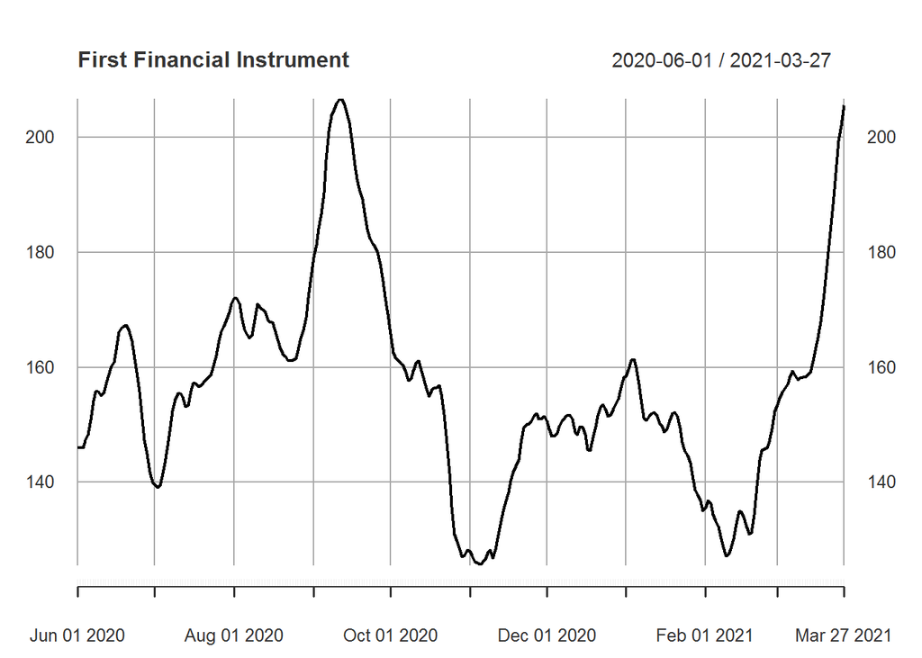

```r
stock1 <- data[ ,1]
stock2 <- data[ ,2]
stock3 <- data[ ,3]
stock4 <- data[ ,4]
stock5 <- data[ ,5]
stock6 <- data[ ,6]
stock7 <- data[ ,7]
stock8 <- data[ ,8]
stock9 <- data[ ,9]
stock10 <- data[ ,10]
plot(stock1, main = "First Financial Instrument")
```

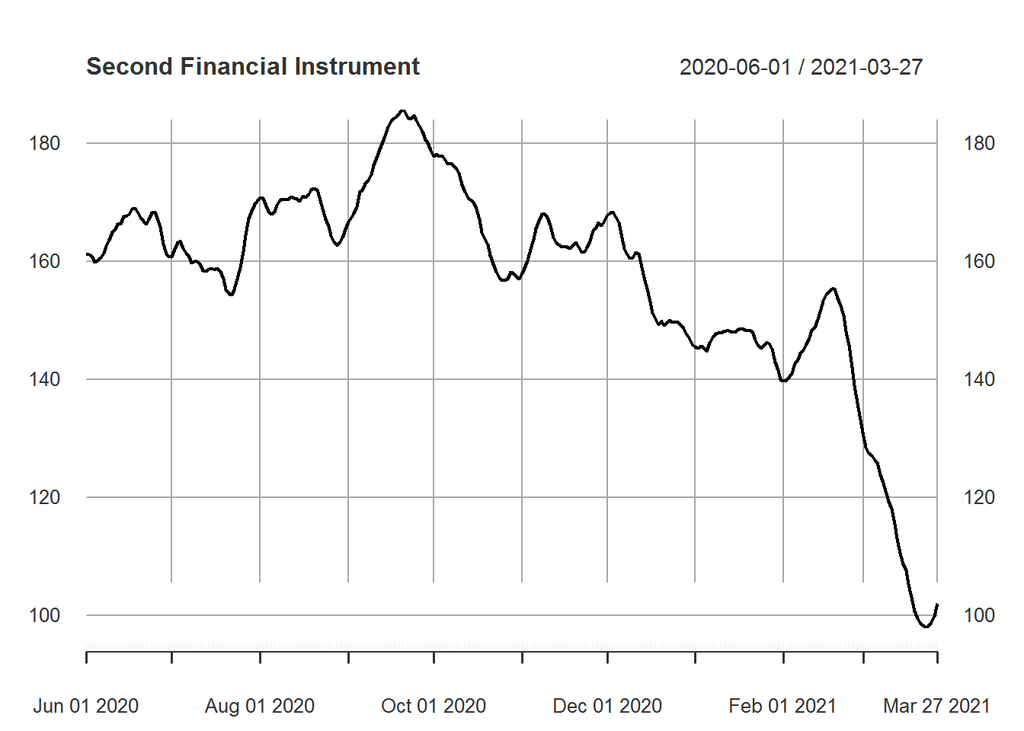

```r
plot(stock2, main = "Second Financial Instrument")
```

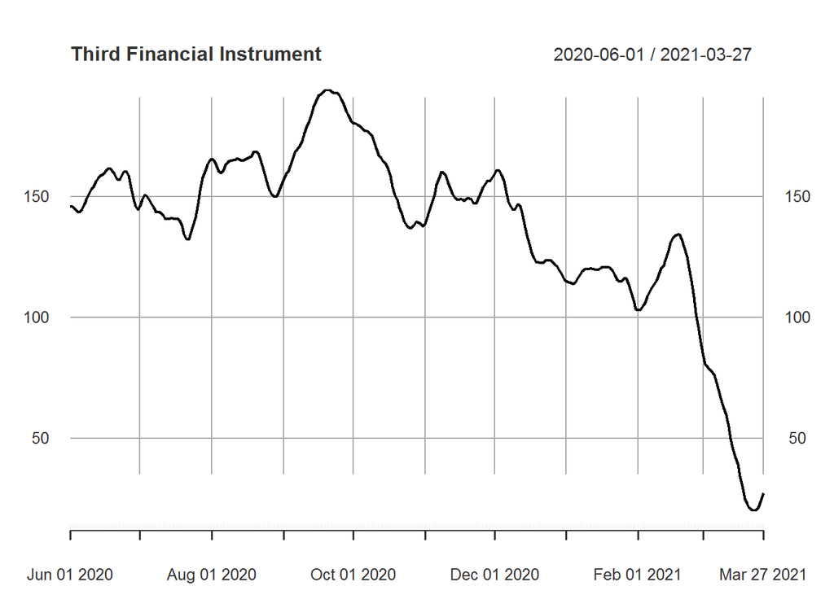

```r
plot(stock3, main = "Third Financial Instrument")
```

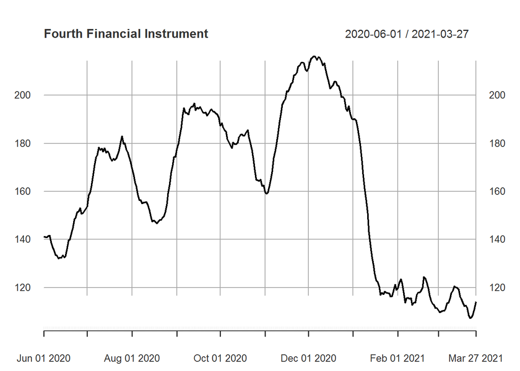

```r
plot(stock4, main = "Fourth Financial Instrument")
```

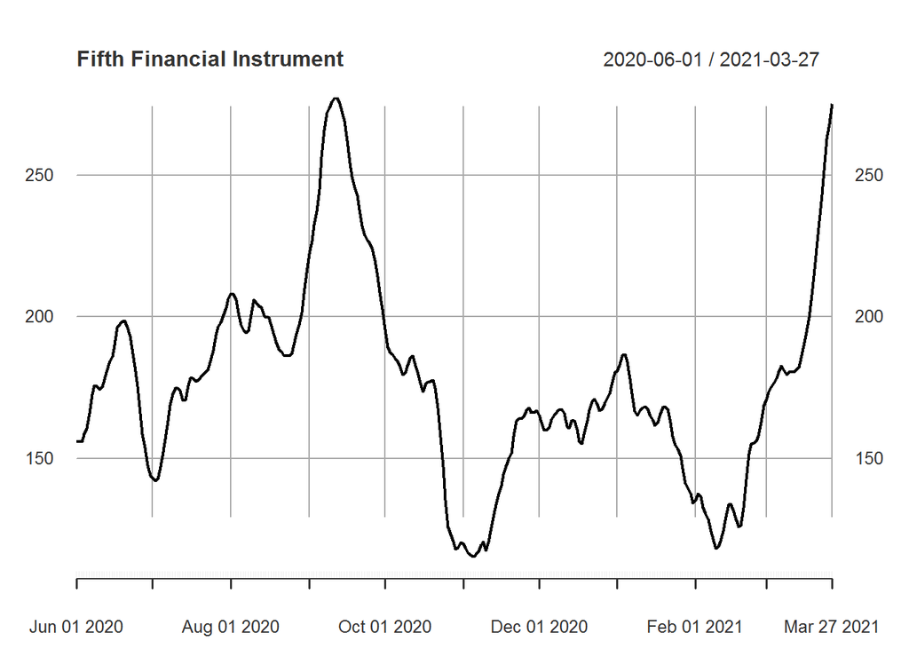

```r
plot(stock5, main = "Fifth Financial Instrument")
```

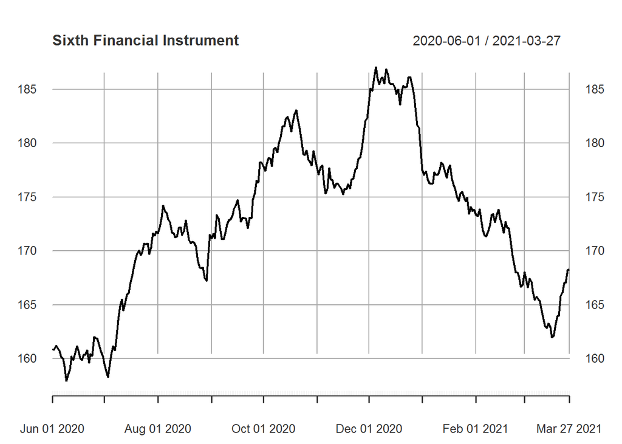

```r
plot(stock6, main = "Sixth Financial Instrument")
```

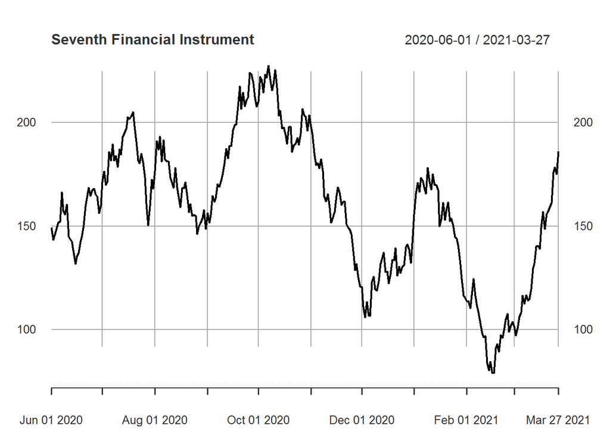

```r
plot(stock7, main = "Seventh Financial Instrument")
```

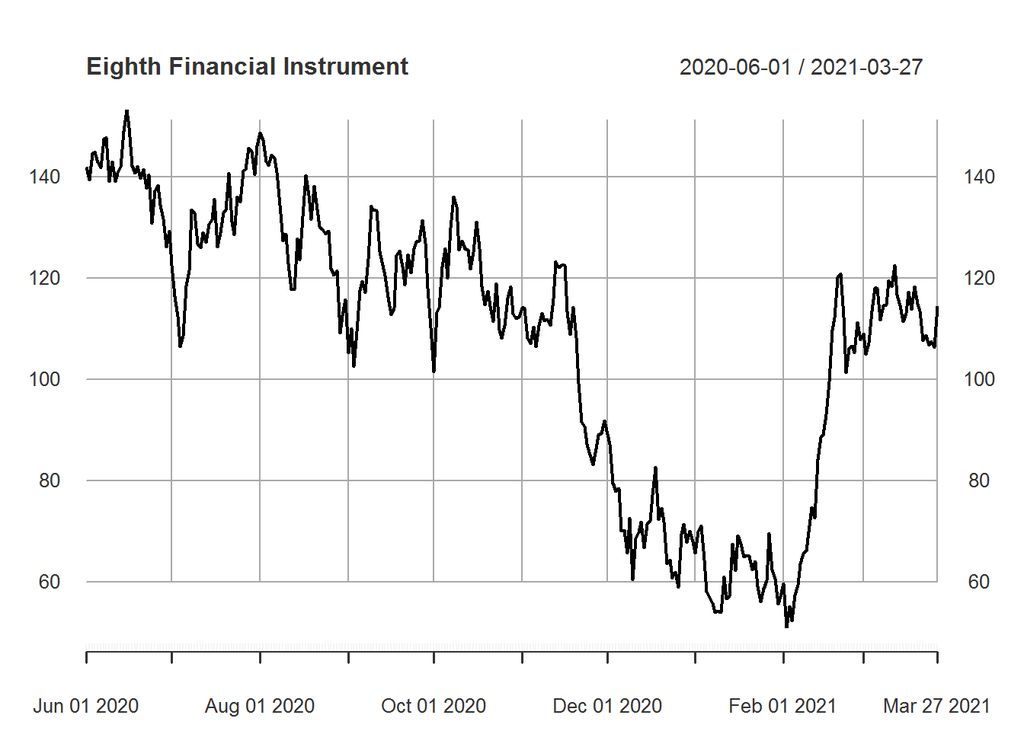

```r
plot(stock8, main = "Eighth Financial Instrument")
```

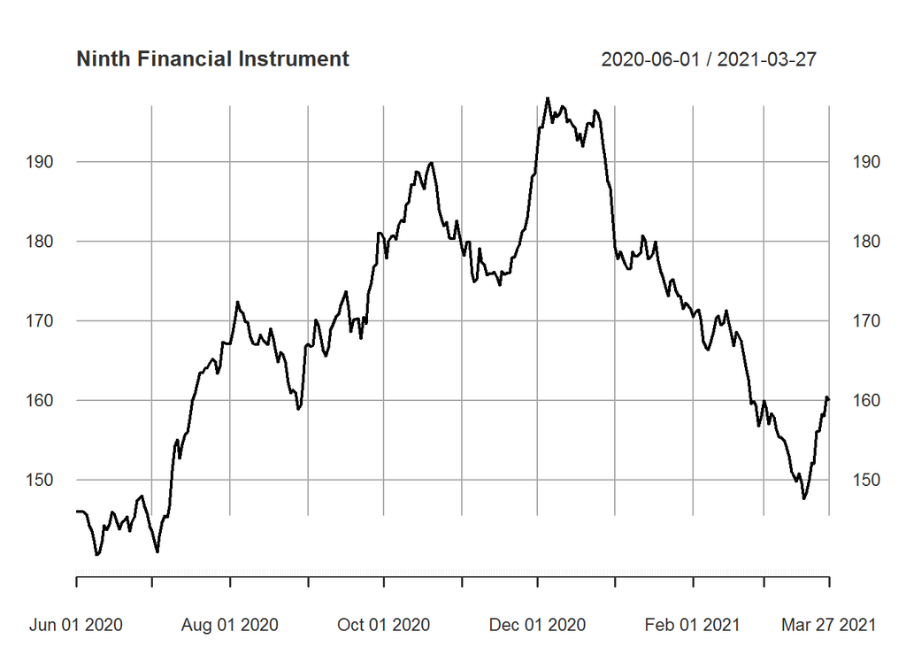

```r
plot(stock9, main = "Ninth Financial Instrument")
```

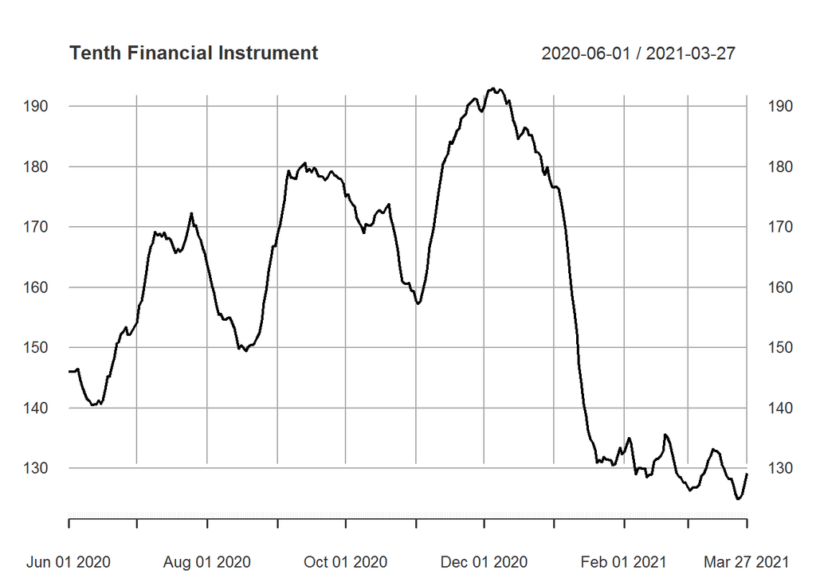

```r
plot(stock10, main = "Tenth Financial Instrument")
```

From the first look it seems that we are dealing with non-stationary time series but we have to run some data diagnostics to have empirical evidence.

- We firstly need to make sure if time series is non-stationarity, if two variables are stationary than cointegration is pointless and we need to ignore that pair.
- Additionally, if two variables have different order of integration than they can’t be cointegrated so we ignore that pair too.
- If the two variables are non-stationarity and have the same order of integration than we move to the next steps of our time series analysis.

*We will make a somewhat an arbitrary decision and select one pair (stock4 and stock10) speculating that this pair have higher chance of being cointegrated and continue with some data diagnostics with this pair.*

# 2 Phillips-Perron (PP) Test

To check for stationarity we will conduct the Phillips-Perron (PP) test. Phillips–Perron test is a unit root test.

That it is used in time series analysis to test the null hypothesis that a time series is integrated of order 1. It builds on the Dickey–Fuller test of the null hypothesis $\rho =1$ in $\Delta y_{t}=(\rho -1)y_{t-1}+u_{t}$, where $\Delta$ is the first difference operator.

Like the augmented Dickey–Fuller test, the Phillips–Perron test addresses the issue that the process generating data for $y_{t}$ might have a higher order of autocorrelation than is admitted in the test equation—making $y_{t-1}$ endogenous and thus invalidating the Dickey–Fuller t-test.

Whilst the augmented Dickey–Fuller test addresses this issue by introducing lags of $\Delta y_{t}$ as regressors in the test equation, the Phillips–Perron test makes a non-parametric correction to the t-test statistic. The test is robust with respect to unspecified autocorrelation and heteroscedasticity in the disturbance process of the test equation.

However, as Davidson and MacKinnon (2004) report, the PP test performs worse in finite samples than the ADF test.

The null and alternative hypotheses are the same as in ADF:

- $H_0:$ time series is not stationary (integrated of order $\ge 1$)
- $H_a:$ time series is stationary (integrated of order $= 0$)

```r
pp.test <- ur.pp(stock4,   # tested series
                 type = c("Z-tau"),     # standardization of the test statistic needed
                 model = c("constant")) # constant deterministic component
                 # which means we assume that any trends in the data are stochastic
summary(pp.test)
```

```
##
## ##################################
## # Phillips-Perron Unit Root Test #
## ##################################
##
## Test regression with intercept
##
##
## Call:
## lm(formula = y ~ y.l1)
##
## Residuals:
##    Min     1Q Median     3Q    Max
## -7.764 -1.340  0.137  1.276  5.747
##
## Coefficients:
##              Estimate Std. Error t value Pr(>|t|)
## (Intercept) -0.180660   0.662587  -0.273    0.785
## y.l1         1.000560   0.004001 250.069   <2e-16 ***
## ---
## Signif. codes:  0 '***' 0.001 '**' 0.01 '*' 0.05 '.' 0.1 ' ' 1
##
## Residual standard error: 2.252 on 297 degrees of freedom
## Multiple R-squared:  0.9953, Adjusted R-squared:  0.9953
## F-statistic: 6.253e+04 on 1 and 297 DF,  p-value: < 2.2e-16
##
##
## Value of test-statistic, type: Z-tau  is: -0.7498
##
##          aux. Z statistics
## Z-tau-mu             0.664
##
## Critical values for Z statistics:
##                      1pct      5pct     10pct
## critical values -3.453891 -2.871351 -2.571959
```

Value of the test-statistic Z-tau (-0.75) is higher than the 5% critical value (-2.871), so we **cannot reject** the null about non-stationarity of our fourth financial instrument.

Let’s test stock4’s first differences:

```r
pp.test.d <- ur.pp(diff.xts(stock4),
                   type = c("Z-tau"),
                   model = c("constant")) # constant deterministic component
summary(pp.test.d)
```

```
##
## ##################################
## # Phillips-Perron Unit Root Test #
## ##################################
##
## Test regression with intercept
##
##
## Call:
## lm(formula = y ~ y.l1)
##
## Residuals:
##     Min      1Q  Median      3Q     Max
## -5.1420 -1.1809  0.0283  1.2668  4.4133
##
## Coefficients:
##             Estimate Std. Error t value Pr(>|t|)
## (Intercept) -0.02710    0.10179  -0.266     0.79
## y.l1         0.63005    0.04537  13.887   <2e-16 ***
## ---
## Signif. codes:  0 '***' 0.001 '**' 0.01 '*' 0.05 '.' 0.1 ' ' 1
##
## Residual standard error: 1.755 on 296 degrees of freedom
## Multiple R-squared:  0.3945, Adjusted R-squared:  0.3925
## F-statistic: 192.9 on 1 and 296 DF,  p-value: < 2.2e-16
##
##
## Value of test-statistic, type: Z-tau  is: -8.3582
##
##          aux. Z statistics
## Z-tau-mu           -0.2766
##
## Critical values for Z statistics:
##                     1pct      5pct     10pct
## critical values -3.45396 -2.871382 -2.571976
```

Value of the test-statistic Z-tau (-8.358) is now lower than the 5% critical value (-2.871), so now we **reject** the null about non-stationarity of stock4’s first differences.

Next we run the same test to stock10.

```r
pp.test <- ur.pp(stock10,   # tested series
                 type = c("Z-tau"),     # standardization of the test statistic needed
                 model = c("constant")) # constant deterministic component
                 # which means we assume that any trends in the data are stochastic
summary(pp.test)
```

```
##
## ##################################
## # Phillips-Perron Unit Root Test #
## ##################################
##
## Test regression with intercept
##
##
## Call:
## lm(formula = y ~ y.l1)
##
## Residuals:
##     Min      1Q  Median      3Q     Max
## -5.0899 -0.8957  0.0806  0.7789  3.8239
##
## Coefficients:
##              Estimate Std. Error t value Pr(>|t|)
## (Intercept) -0.150875   0.637660  -0.237    0.813
## y.l1         1.000595   0.003969 252.080   <2e-16 ***
## ---
## Signif. codes:  0 '***' 0.001 '**' 0.01 '*' 0.05 '.' 0.1 ' ' 1
##
## Residual standard error: 1.396 on 297 degrees of freedom
## Multiple R-squared:  0.9953, Adjusted R-squared:  0.9953
## F-statistic: 6.354e+04 on 1 and 297 DF,  p-value: < 2.2e-16
##
##
## Value of test-statistic, type: Z-tau  is: -0.7455
##
##          aux. Z statistics
## Z-tau-mu            0.6937
##
## Critical values for Z statistics:
##                      1pct      5pct     10pct
## critical values -3.453891 -2.871351 -2.571959
```

Value of the test-statistic Z-tau (-0.746) is higher than the 5% critical value (-2.871), so we **cannot reject** the null about non-stationarity of our tenth financial instrument.

Let’s also test stock10’s first differences:

```r
pp.test.d <- ur.pp(diff.xts(stock10),
                   type = c("Z-tau"),
                   model = c("constant")) # constant deterministic component
summary(pp.test.d)
```

```
##
## ##################################
## # Phillips-Perron Unit Root Test #
## ##################################
##
## Test regression with intercept
##
##
## Call:
## lm(formula = y ~ y.l1)
##
## Residuals:
##     Min      1Q  Median      3Q     Max
## -3.4527 -0.7664  0.1164  0.7195  2.6853
##
## Coefficients:
##             Estimate Std. Error t value Pr(>|t|)
## (Intercept) -0.01629    0.06244  -0.261    0.794
## y.l1         0.64010    0.04489  14.260   <2e-16 ***
## ---
## Signif. codes:  0 '***' 0.001 '**' 0.01 '*' 0.05 '.' 0.1 ' ' 1
##
## Residual standard error: 1.077 on 296 degrees of freedom
## Multiple R-squared:  0.4072, Adjusted R-squared:  0.4052
## F-statistic: 203.3 on 1 and 296 DF,  p-value: < 2.2e-16
##
##
## Value of test-statistic, type: Z-tau  is: -8.1879
##
##          aux. Z statistics
## Z-tau-mu           -0.2696
##
## Critical values for Z statistics:
##                     1pct      5pct     10pct
## critical values -3.45396 -2.871382 -2.571976
```

Value of the test-statistic Z-tau (-8.188) is now lower than the 5% critical value (-2.871), so now we **reject** the null about non-stationarity of stock10’s first differences.

As a result we can estimate that `stock4` and `stock10` have the same order of integration ~ `I(1)` but we have to run further tests to confirm.

# 3 Cointegration testing

First we plot both variables on the graph:

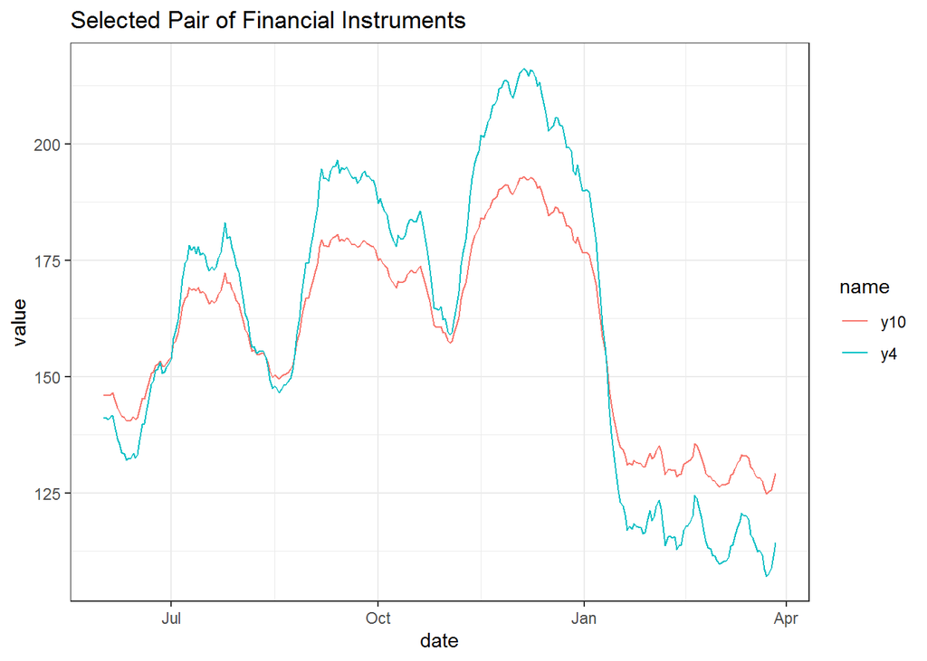

```r
cbind(stock4, stock10) %>%
  as_tibble() %>%
  mutate(date = index(data)) %>%
  pivot_longer(!date) %>%
  ggplot(aes(date, value, col = name)) +
  geom_line() +
  theme_bw() +
  labs(
    title = "Selected Pair of Financial Instruments")
```

We will work the the `stock4` and `stock10` variables. Let’s create their first differences.

```r
dy4 <- diff.xts(stock4)
dy10 <- diff.xts(stock10)
```

To estimate the cointegrating vector, we will estimate the following model:

```r
model.coint <- lm(stock4 ~ stock10, data=data)
```

Let’s examine the model summary:

```r
summary(model.coint)
```

```
##
## Call:
## lm(formula = stock4 ~ stock10, data = data)
##
## Residuals:
##      Min       1Q   Median       3Q      Max
## -0.43242 -0.11995  0.01077  0.11875  0.56887
##
## Coefficients:
##                Estimate  Std. Error t value Pr(>|t|)
## (Intercept) -92.6335839   0.0839866   -1103   <2e-16 ***
## stock10       1.6002374   0.0005231    3059   <2e-16 ***
## ---
## Signif. codes:  0 '***' 0.001 '**' 0.01 '*' 0.05 '.' 0.1 ' ' 1
##
## Residual standard error: 0.1847 on 298 degrees of freedom
## Multiple R-squared:      1,  Adjusted R-squared:      1
## F-statistic: 9.358e+06 on 1 and 298 DF,  p-value: < 2.2e-16
```

Next, we have to test stationarity of residuals. What is the proper ADF statistic?

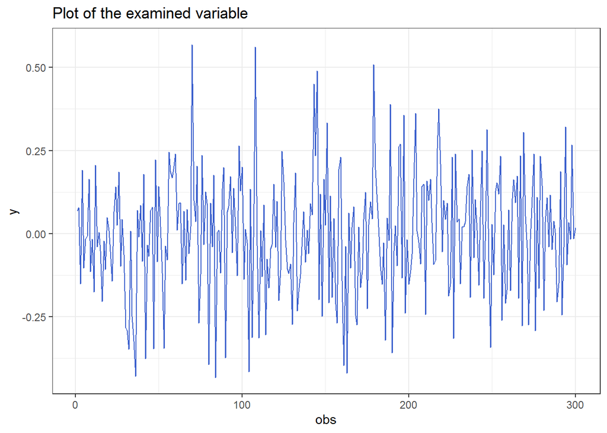

```
##   augmentations        adf p_adf     bgodfrey      p_bg
## 1             0 -18.278777  0.01 0.0069216469 0.9336953
## 2             1 -11.409105  0.01 0.0044811249 0.9466285
## 3             2  -9.723912  0.01 0.0007541970 0.9780907
## 4             3  -8.776617  0.01 0.0001483138 0.9902833
```

```r
testdf(variable = residuals(model.coint), max.augmentations = 3)
```

What is the result of cointegration test? What is the cointegrating vector?

The ADF test with no augmentations can be used its result is that non-stationarity of residuals is **STRONGLY REJECTED**, so residuals are **stationary**, which means that `stock4` and `stock10` are **cointegrated**.

The cointegrating vector is [1, 92.634 , -1.6]

which defines the cointegrating relationship as: 1 * stock4 - -92.634 - 1.6 * stock10,

Now, we established that stock4 and stock10 are cointegrated we ignore other variables of our dataset

```r
ourpair <- cbind(stock4, stock10)
```

Next, we create first lags of residuals and adding them to the dataset

```r
ourpair$lresid <- lag.xts(residuals(model.coint))
```

# 4 Granger causality test

Now let’s check, whether `stock10` Granger causes `stock4` and vice versa. What is the proper lag length in this case?

Let’s try with 3 lags. First, the `stock10` as the dependent variable:

```r
grangertest(y10 ~ y4,
            data = ourpair,
            order = 3) # lag assumed
```

```
## Granger causality test
##
## Model 1: y10 ~ Lags(y10, 1:3) + Lags(y4, 1:3)
## Model 2: y10 ~ Lags(y10, 1:3)
##   Res.Df Df      F    Pr(>F)
## 1    290
## 2    293 -3 5.9916 0.0005657 ***
## ---
## Signif. codes:  0 '***' 0.001 '**' 0.01 '*' 0.05 '.' 0.1 ' ' 1
```

Is `stock4` a Granger cause of `stock10`?

Next, the `stock4` as the dependent variable.

```r
grangertest(y4 ~ y10,
            data = ourpair,
            order = 3) # lag assumed
```

```
## Granger causality test
##
## Model 1: y4 ~ Lags(y4, 1:3) + Lags(y10, 1:3)
## Model 2: y4 ~ Lags(y4, 1:3)
##   Res.Df Df      F     Pr(>F)
## 1    290
## 2    293 -3 9.9679 0.00000284 ***
## ---
## Signif. codes:  0 '***' 0.001 '**' 0.01 '*' 0.05 '.' 0.1 ' ' 1
```

Is `stock10` a Granger cause of `stock4`?

In both cases the null about **NO CAUSALITY** is **rejected**, at least at the 95% confidence level.

Now, let’s repeat the analysis for 4 lags.

```r
grangertest(y10 ~ y4,
            data = ourpair,
            order = 4) # lag assumed
```

```
## Granger causality test
##
## Model 1: y10 ~ Lags(y10, 1:4) + Lags(y4, 1:4)
## Model 2: y10 ~ Lags(y10, 1:4)
##   Res.Df Df      F Pr(>F)
## 1    287
## 2    291 -4 4.5969 0.0013 **
## ---
## Signif. codes:  0 '***' 0.001 '**' 0.01 '*' 0.05 '.' 0.1 ' ' 1
```

```r
grangertest(y4 ~ y10,
            data = ourpair,
            order = 4) # lag assumed
```

```
## Granger causality test
##
## Model 1: y4 ~ Lags(y4, 1:4) + Lags(y10, 1:4)
## Model 2: y4 ~ Lags(y4, 1:4)
##   Res.Df Df      F      Pr(>F)
## 1    287
## 2    291 -4 7.9933 0.000004022 ***
## ---
## Signif. codes:  0 '***' 0.001 '**' 0.01 '*' 0.05 '.' 0.1 ' ' 1
```

Is `stock10` a Granger cause of `stock4`?

Again, let’s repeat the analysis for 5 lags:

```r
grangertest(y10 ~ y4,
            data = ourpair,
            order = 5) # lag assumed
```

```
## Granger causality test
##
## Model 1: y10 ~ Lags(y10, 1:5) + Lags(y4, 1:5)
## Model 2: y10 ~ Lags(y10, 1:5)
##   Res.Df Df      F   Pr(>F)
## 1    284
## 2    289 -5 3.8994 0.001959 **
## ---
## Signif. codes:  0 '***' 0.001 '**' 0.01 '*' 0.05 '.' 0.1 ' ' 1
```

Is `stock4` a Granger cause of `stock10`?

```r
grangertest(y4 ~ y10,
            data = ourpair,
            order = 5) # lag assumed
```

```
## Granger causality test
##
## Model 1: y4 ~ Lags(y4, 1:5) + Lags(y10, 1:5)
## Model 2: y4 ~ Lags(y4, 1:5)
##   Res.Df Df      F      Pr(>F)
## 1    284
## 2    289 -5 6.6055 0.000007783 ***
## ---
## Signif. codes:  0 '***' 0.001 '**' 0.01 '*' 0.05 '.' 0.1 ' ' 1
```

Is `stock10` a Granger cause of `stock4`?

What is the conclusion?

At 5% significance level (or 95% confidence level) we have so called **bi-directional feedback** in all cases.

Now, we have to note, that the Granger causality analysis above is based on the **non-stationary** time series. If we wanted to remove risks of getting spurious regressions, we should rather use the **differenced** time series.

Let’s do the same process for first differencies

```r
grangertest(dy4[-1,] ~ dy10[-1,],
            data = ourpair,
            order = 3) # lag assumed
```

```
## Granger causality test
##
## Model 1: dy4[-1, ] ~ Lags(dy4[-1, ], 1:3) + Lags(dy10[-1, ], 1:3)
## Model 2: dy4[-1, ] ~ Lags(dy4[-1, ], 1:3)
##   Res.Df Df      F Pr(>F)
## 1    289
## 2    292 -3 2.9941 0.0312 *
## ---
## Signif. codes:  0 '***' 0.001 '**' 0.01 '*' 0.05 '.' 0.1 ' ' 1
```

Is the null about **NO CAUSALITY** still **rejected**?

Let’s make `stock10` as the dependent variable.

```r
grangertest(dy10[-1,] ~ dy4[-1,],#removing the first data entry which is N/A
            data = ourpair,
            order = 3) # lag assumed
```

```
## Granger causality test
##
## Model 1: dy10[-1, ] ~ Lags(dy10[-1, ], 1:3) + Lags(dy4[-1, ], 1:3)
## Model 2: dy10[-1, ] ~ Lags(dy10[-1, ], 1:3)
##   Res.Df Df      F Pr(>F)
## 1    289
## 2    292 -3 1.5188 0.2097
```

The result changed, now we cannot reject the null about **NO CAUSALITY**.

Let’s repeat the same process with 4 lags.

```r
grangertest(dy4[-1,] ~ dy10[-1,], #removing the first data entry which is N/A
            data = ourpair,
            order = 4) # lag assumed
```

```
## Granger causality test
##
## Model 1: dy4[-1, ] ~ Lags(dy4[-1, ], 1:4) + Lags(dy10[-1, ], 1:4)
## Model 2: dy4[-1, ] ~ Lags(dy4[-1, ], 1:4)
##   Res.Df Df      F  Pr(>F)
## 1    286
## 2    290 -4 3.2618 0.01228 *
## ---
## Signif. codes:  0 '***' 0.001 '**' 0.01 '*' 0.05 '.' 0.1 ' ' 1
```

Null hypothesis about **NO CAUSALITY** still **rejected**.

```r
grangertest(dy10[-1,] ~ dy4[-1,], #removing the first data entry which is N/A
            data = ourpair,
            order = 4) # lag assumed
```

```
## Granger causality test
##
## Model 1: dy10[-1, ] ~ Lags(dy10[-1, ], 1:4) + Lags(dy4[-1, ], 1:4)
## Model 2: dy10[-1, ] ~ Lags(dy10[-1, ], 1:4)
##   Res.Df Df      F Pr(>F)
## 1    286
## 2    290 -4 1.8008 0.1287
```

# 5 VAR model Estimation

Since we observed bi-directional causality we can try to estimate a bi-variate VAR model. First we bind our analyzed variables

```r
y4_y10 <- cbind(stock4, stock10)
```

To consider the degree of persistence in the data we make use of the autocorrelation function.

First question: what is the proper order (lag length) of the VAR model? We may use information criteria to get some hints about it.

```r
VARselect(y4_y10, # input data for VAR
          lag.max = 6)     # maximum lag
```

```
## $selection
## AIC(n)  HQ(n)  SC(n) FPE(n)
##      3      3      3      3
##
## $criteria
##                  1           2           3          4           5           6
## AIC(n) -2.70429235 -3.22356873 -3.30678717 -3.3000754 -3.28805062 -3.26998531
## HQ(n)  -2.67418699 -3.17339314 -3.23654134 -3.2097593 -3.17766431 -3.13952876
## SC(n)  -2.62911725 -3.09827690 -3.13137861 -3.0745501 -3.01240860 -2.94422656
## FPE(n)  0.06691776  0.03981298  0.03663434  0.0368818  0.03732915  0.03801137
```

Perhaps it would be easier if we slightly reorganize the output:

```r
VARselect(y4_y10, lag.max = 6) %>%
  .$criteria %>%
  t() %>%
  as_tibble() %>%
  mutate(nLags = 1:nrow(.)) %>%
  #select(nLags, everything()) %>%
  kbl(digits = 3) %>%
  kable_classic("striped", full_width = F)
```

| AIC(n) | HQ(n) | SC(n) | FPE(n) | nLags |
| --- | --- | --- | --- | --- |
| -2.704 | -2.674 | -2.629 | 0.067 | 1 |
| -3.224 | -3.173 | -3.098 | 0.040 | 2 |
| -3.307 | -3.237 | -3.131 | 0.037 | 3 |
| -3.300 | -3.210 | -3.075 | 0.037 | 4 |
| -3.288 | -3.178 | -3.012 | 0.037 | 5 |
| -3.270 | -3.140 | -2.944 | 0.038 | 6 |

All criteria suggest order 3. Notice!: the smaller value of information criteria, the better the model!

What about potential seasonality? Than we need to include seasonal dummies, the option `season =` is responsible for that.

```r
library(formattable)
VARselect(y4_y10,         # input data for VAR
          lag.max = 6,     # maximum lag
          season = 12)     # seasonal frequency
```

```
## $selection
## AIC(n)  HQ(n)  SC(n) FPE(n)
##      3      3      3      3
##
## $criteria
##                  1           2           3           4           5           6
## AIC(n) -2.62619940 -3.16523350 -3.25888965 -3.24764083 -3.23022864 -3.21458681
## HQ(n)  -2.48570773 -3.00467159 -3.07825750 -3.04693844 -3.00945601 -2.97374394
## SC(n)  -2.27538228 -2.76429965 -2.80783906 -2.74647351 -2.67894459 -2.61318603
## FPE(n)  0.07236336  0.04221337  0.03844283  0.03888215  0.03957063  0.04020119
```

```r
VARselect(y4_y10, lag.max = 6, season = 12) %>%
  .$criteria %>%
  t() %>%
  as_tibble() %>%
  mutate(nLags = 1:nrow(.)) %>%
  #select(nLags, everything()) %>%
  kbl(digits = 3) %>%
  kable_classic("striped", full_width = F)
```

| AIC(n) | HQ(n) | SC(n) | FPE(n) | nLags |
| --- | --- | --- | --- | --- |
| -2.626 | -2.486 | -2.275 | 0.072 | 1 |
| -3.165 | -3.005 | -2.764 | 0.042 | 2 |
| -3.259 | -3.078 | -2.808 | 0.038 | 3 |
| -3.248 | -3.047 | -2.746 | 0.039 | 4 |
| -3.230 | -3.009 | -2.679 | 0.040 | 5 |
| -3.215 | -2.974 | -2.613 | 0.040 | 6 |

Again all information criteria suggest the use of three lags.

As a result, let’s estimate the model with 3 lags and seasonal dummies.

```r
y4_y10.var3 <- VAR(y4_y10,
                    p = 3,  # order of VAR model
                    season = 12)
```

Now, let’s examine the summary of the model:

```r
summary(y4_y10.var3)
```

```
##
## VAR Estimation Results:
## =========================
## Endogenous variables: y4, y10
## Deterministic variables: const
## Sample size: 297
## Log Likelihood: -323.006
## Roots of the characteristic polynomial:
## 0.981 0.8244 0.4763 0.3042 0.3042 0.2758
## Call:
## VAR(y = y4_y10, p = 3, season = 12L)
##
##
## Estimation results for equation y4:
## ===================================
## y4 = y4.l1 + y10.l1 + y4.l2 + y10.l2 + y4.l3 + y10.l3 + const + sd1 + sd2 + sd3 + sd4 + sd5 + sd6 + sd7 + sd8 + sd9 + sd10 + sd11
##
##         Estimate Std. Error t value    Pr(>|t|)
## y4.l1    -0.7788     0.5215  -1.493     0.13648
## y10.l1    3.5076     0.8305   4.223 0.000032613 ***
## y4.l2    -1.4386     0.5244  -2.743     0.00647 **
## y10.l2    2.0751     0.8578   2.419     0.01619 *
## y4.l3    -1.6259     0.5311  -3.061     0.00242 **
## y10.l3    2.1607     0.8562   2.524     0.01217 *
## const  -447.5632    87.9037  -5.092 0.000000654 ***
## sd1      -0.5203     0.4594  -1.133     0.25838
## sd2      -1.3448     0.4612  -2.916     0.00383 **
## sd3      -0.9934     0.4627  -2.147     0.03268 *
## sd4      -0.2514     0.4542  -0.553     0.58044
## sd5      -0.4959     0.4555  -1.089     0.27727
## sd6      -0.9169     0.4548  -2.016     0.04475 *
## sd7      -0.6175     0.4591  -1.345     0.17971
## sd8      -0.7690     0.4566  -1.684     0.09326 .
## sd9      -0.7471     0.4596  -1.625     0.10519
## sd10     -1.3854     0.4559  -3.039     0.00260 **
## sd11     -0.7972     0.4586  -1.738     0.08325 .
## ---
## Signif. codes:  0 '***' 0.001 '**' 0.01 '*' 0.05 '.' 0.1 ' ' 1
##
##
```

[output cut: 32 more lines]

```
## Residual standard error: 1.008 on 279 degrees of freedom
## Multiple R-Squared: 0.9977,  Adjusted R-squared: 0.9976
## F-statistic:  7162 on 17 and 279 DF,  p-value: < 2.2e-16
##
##
##
## Covariance matrix of residuals:
##        y4   y10
## y4  2.571 1.606
## y10 1.606 1.017
##
## Correlation matrix of residuals:
##         y4    y10
## y4  1.0000 0.9934
## y10 0.9934 1.0000
```

Let’s do some basic diagnostics:

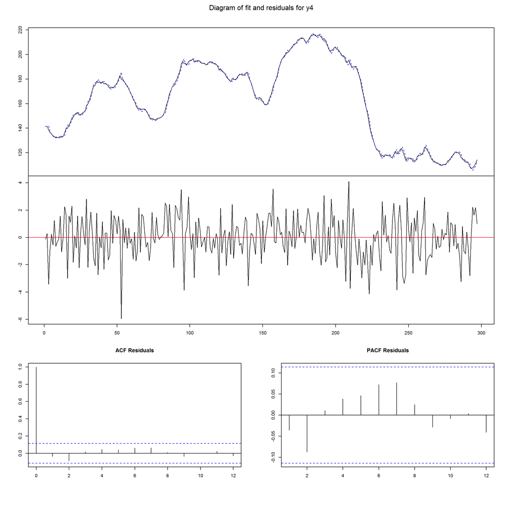

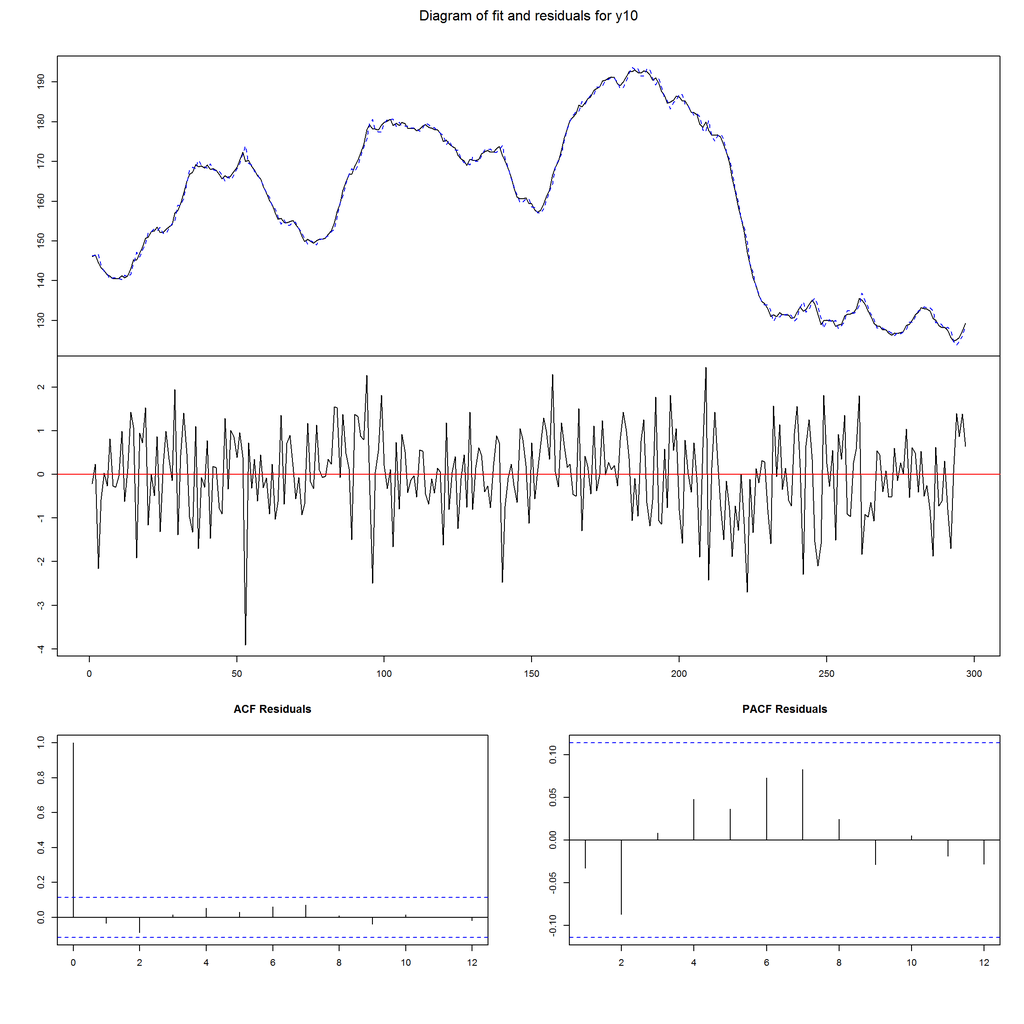

```r
plot(y4_y10.var3)
```

The panels present:

- panel 1: original and fitted values
- panel 2: residuals from the model
- panel 3: ACF and PACF for residuals

Alternatively, we could use the Breusch-Godfrey (BG) test:

```r
serial.test(y4_y10.var3, type = "BG")
```

```
##
##  Breusch-Godfrey LM test
##
## data:  Residuals of VAR object y4_y10.var3
## Chi-squared = 20.784, df = 20, p-value = 0.41
```

Let’s now perform the Portmanteau test to verify the null hypothesis of nO autocorrelation of residuals.

```r
serial.test(y4_y10.var3)
```

```
##
##  Portmanteau Test (asymptotic)
##
## data:  Residuals of VAR object y4_y10.var3
## Chi-squared = 46.843, df = 52, p-value = 0.6763
```

# 6 Forecast Error Variance Decomposition

To generate the forecast error variance decomposition we make use of the fevd command, where we set the number of steps ahead to ten.

The variance decomposition indicates the amount of information each variable contributes to the other variables in the auto-regression. It determines how much of the forecast error variance of each of the variables can be explained by exogenous shocks to the other variables.

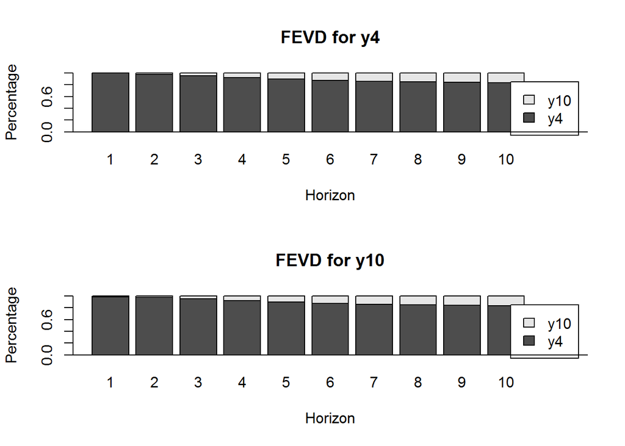

```r
plot(fevd(y4_y10.var3, n.ahead = 10))
```

# 7 Forecasting with VAR

To forecast forward we can make use of the predict command, where in this case we are forecasting 10 steps ahead. We are also looking to make use of 95% confidence intervals for the forecast.

Lets estimate a model on a shorter sample:

```r
tail(y4_y10, 15)
```

```
##                y4    y10
## 2021-03-13 120.07 132.95
## 2021-03-14 120.06 132.89
## 2021-03-15 119.29 132.43
## 2021-03-16 116.12 130.58
## 2021-03-17 115.36 130.07
## 2021-03-18 113.68 128.81
## 2021-03-19 112.32 128.23
## 2021-03-20 112.62 128.29
## 2021-03-21 111.67 127.47
## 2021-03-22 108.55 125.78
## 2021-03-23 107.11 124.80
## 2021-03-24 107.70 125.20
## 2021-03-25 108.88 125.76
## 2021-03-26 111.27 127.43
## 2021-03-27 114.23 129.26
```

```r
y4_y10.short <- y4_y10["/2021-03-18",]
tail(y4_y10.short)
```

```
##                y4    y10
## 2021-03-13 120.07 132.95
## 2021-03-14 120.06 132.89
## 2021-03-15 119.29 132.43
## 2021-03-16 116.12 130.58
## 2021-03-17 115.36 130.07
## 2021-03-18 113.68 128.81
```

VAR model estimation on a shorter sample:

```r
y4_y10.var3.short <- VAR(y4_y10.short,
                          p = 3,
                          season = 12)
```

Now, let’s and run the forecasts:

```r
y4_y10.var3.forecast <- predict(y4_y10.var3.short,
                                 n.ahead = 10,
                                 ci = 0.95) # 95% confidence interval
```

Lets see the result:

```r
y4_y10.var3.forecast
```

```
## $y4
##           fcst     lower    upper        CI
##  [1,] 113.6276 110.49010 116.7651  3.137507
##  [2,] 113.5284 108.08613 118.9706  5.442242
##  [3,] 113.1847 105.06382 121.3055  8.120864
##  [4,] 113.6517 102.73590 124.5674 10.915751
##  [5,] 113.9969 100.26874 127.7250 13.728154
##  [6,] 114.6537  98.15992 131.1475 16.493781
##  [7,] 114.5630  95.39358 133.7323 19.169380
##  [8,] 114.8419  93.10311 136.5806 21.738741
##  [9,] 115.7143  91.52458 139.9039 24.189675
## [10,] 116.4009  89.88174 142.9200 26.519120
##
## $y10
##           fcst    lower    upper        CI
##  [1,] 128.9068 126.9324 130.8812  1.974395
##  [2,] 128.8179 125.3964 132.2394  3.421501
##  [3,] 128.6862 123.5924 133.7800  5.093800
##  [4,] 128.9124 122.0746 135.7503  6.837844
##  [5,] 129.1736 120.5786 137.7687  8.595083
##  [6,] 129.5334 119.2109 139.8559 10.322496
##  [7,] 129.4870 117.4931 141.4808 11.993843
##  [8,] 129.6292 116.0307 143.2277 13.598524
##  [9,] 130.1718 115.0425 145.3011 15.129256
## [10,] 130.6240 114.0400 147.2081 16.584032
```

```r
str(y4_y10.var3.forecast)
```

[output not shown]

[output cut: 146 more lines]

```
##   .. ..$ sd11  : num [1:288] -0.0833 -0.0833 -0.0833 -0.0833 -0.0833 ...
##   ..$ y           : num [1:291, 1:2] 141 141 141 141 142 ...
##   .. ..- attr(*, "dimnames")=List of 2
##   .. .. ..$ : chr [1:291] "2020-06-01" "2020-06-02" "2020-06-03" "2020-06-04" ...
##   .. .. ..$ : chr [1:2] "y4" "y10"
##   ..$ type        : chr "const"
##   ..$ p           : num 3
##   ..$ K           : int 2
##   ..$ obs         : num 288
##   ..$ totobs      : num 291
##   ..$ restrictions: NULL
##   ..$ call        : language VAR(y = y4_y10.short, p = 3, season = 12L)
##   ..- attr(*, "class")= chr "varest"
##  $ exo.fcst: NULL
##  - attr(*, "class")= chr "varprd"
```

Forecasts are in the first element called `$fcst`.

VAR forecasts for `y4`:

```r
y4_y10.var3.forecast$fcst$y4
```

```
##           fcst     lower    upper        CI
##  [1,] 113.6276 110.49010 116.7651  3.137507
##  [2,] 113.5284 108.08613 118.9706  5.442242
##  [3,] 113.1847 105.06382 121.3055  8.120864
##  [4,] 113.6517 102.73590 124.5674 10.915751
##  [5,] 113.9969 100.26874 127.7250 13.728154
##  [6,] 114.6537  98.15992 131.1475 16.493781
##  [7,] 114.5630  95.39358 133.7323 19.169380
##  [8,] 114.8419  93.10311 136.5806 21.738741
##  [9,] 115.7143  91.52458 139.9039 24.189675
## [10,] 116.4009  89.88174 142.9200 26.519120
```

VAR forecasts for `y10`:

```r
y4_y10.var3.forecast$fcst$y10
```

```
##           fcst    lower    upper        CI
##  [1,] 128.9068 126.9324 130.8812  1.974395
##  [2,] 128.8179 125.3964 132.2394  3.421501
##  [3,] 128.6862 123.5924 133.7800  5.093800
##  [4,] 128.9124 122.0746 135.7503  6.837844
##  [5,] 129.1736 120.5786 137.7687  8.595083
##  [6,] 129.5334 119.2109 139.8559 10.322496
##  [7,] 129.4870 117.4931 141.4808 11.993843
##  [8,] 129.6292 116.0307 143.2277 13.598524
##  [9,] 130.1718 115.0425 145.3011 15.129256
## [10,] 130.6240 114.0400 147.2081 16.584032
```

Lets store it as an `xts` object. Correct set of dates (index) can be extracted from the original `xts` data object.

```r
tail(index(y4_y10), 10)
```

```
##  [1] "2021-03-18" "2021-03-19" "2021-03-20" "2021-03-21" "2021-03-22"
##  [6] "2021-03-23" "2021-03-24" "2021-03-25" "2021-03-26" "2021-03-27"
```

Hence, we can build the `xts` object:

```r
y4_forecast <- xts(y4_y10.var3.forecast$fcst$y4[,-4],
                    # we exclude the last column with CI
                    tail(index(y4_y10), 10))
```

Now, we will change the names:

```r
names(y4_forecast)
```

```
## [1] "fcst"  "lower" "upper"
```

```r
names(y4_forecast) <- c("Y4_fore", "Y4_lower", "Y4_upper")
```

Lets do the same for `y10` forecasts:

```r
y10_forecast <- xts(y4_y10.var3.forecast$fcst$y10[,-4],
                    # we exclude the last column with CI
                    tail(index(y4_y10), 10))
names(y10_forecast) <- c("Y10_fore", "Y10_lower", "Y10_upper")
```

Now, we can merge all three objects together.

```r
y4_y10 <- merge(y4_y10,
                 y4_forecast,
                 y10_forecast)
```

Lets compare the forecasts and real data on the plot.

Plot of `y4` forecasts:

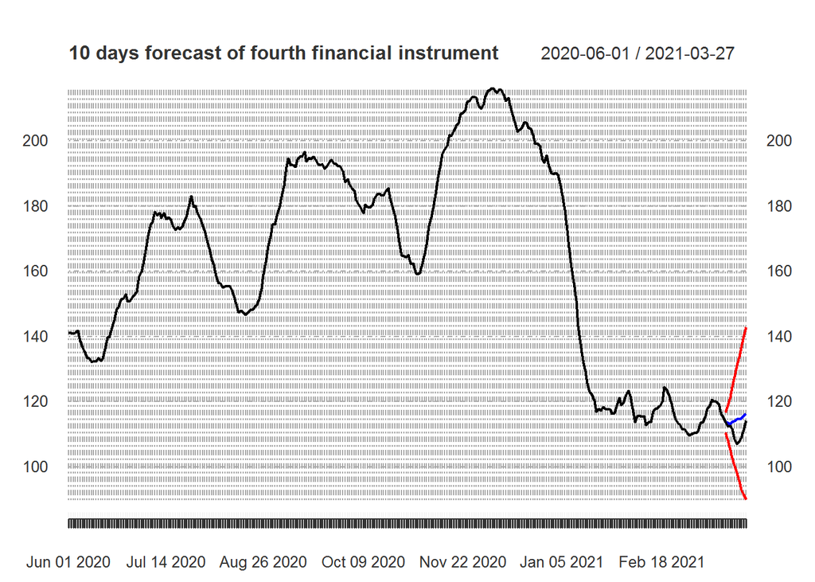

```r
plot(y4_y10[, c("y4", "Y4_fore",
                 "Y4_lower", "Y4_upper")],
     major.ticks = "days",
     grid.ticks.on = "days",
     grid.ticks.lty = 10,
     main = "10 days forecast of fourth financial instrument",
     col = c("black", "blue", "red", "red"))
```

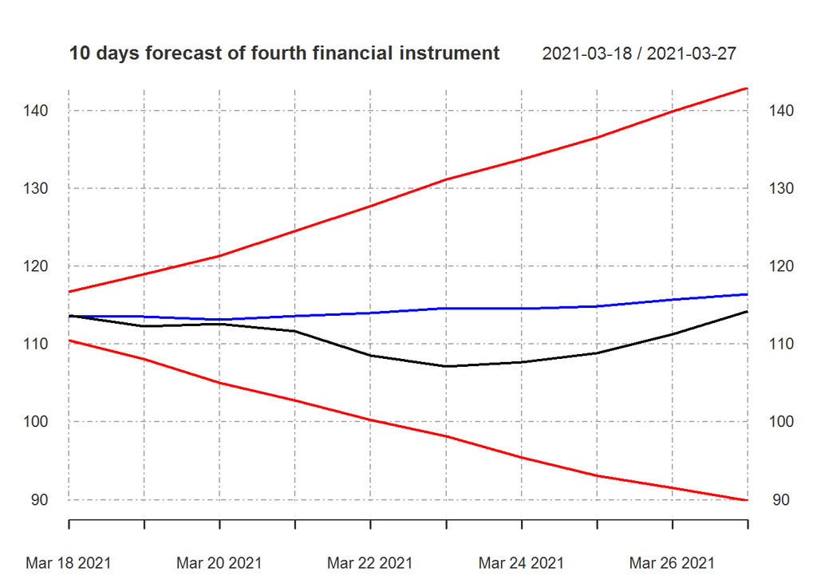

```r
plot(y4_y10["2021-03-18/", c("y4", "Y4_fore",
                        "Y4_lower", "Y4_upper")],
     major.ticks = "days",
     grid.ticks.on = "days",
     grid.ticks.lty = 10,
     main = "10 days forecast of fourth financial instrument",
     col = c("black", "blue", "red", "red"))
```

The assessment of any forecast is of relative character. It always depends on at least one alternative way of forecasting these values!

Plot of `y10` forecasts for last ten days:

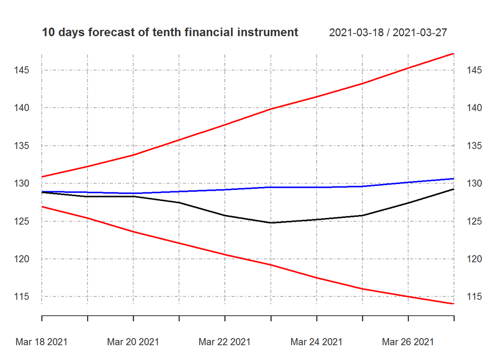

```r
plot(y4_y10["2021-03-18/", c("y10", "Y10_fore",
                        "Y10_lower", "Y10_upper")],
     major.ticks = "days",
     grid.ticks.on = "days",
     grid.ticks.lty = 10,
     main = "10 days forecast of tenth financial instrument",
     col = c("black", "blue", "red", "red"))
```

Lets calculate forecast accuracy measures.

```r
y4_y10$mae.y10   <-  abs(y4_y10$y10 - y4_y10$Y10_fore)
y4_y10$mse.y10   <-  (y4_y10$y10 - y4_y10$Y10_fore) ^ 2
y4_y10$mape.y10  <-  abs((y4_y10$y10 - y4_y10$Y10_fore)/y4_y10$y10)
y4_y10$amape.y10 <-  abs((y4_y10$y10 - y4_y10$Y10_fore) /
                            (y4_y10$y10 + y4_y10$Y10_fore))

y4_y10$mae.y4   <-  abs(y4_y10$y4 - y4_y10$Y4_fore)
y4_y10$mse.y4   <-  (y4_y10$y4 - y4_y10$Y4_fore) ^ 2
y4_y10$mape.y4  <-  abs((y4_y10$y4 - y4_y10$Y4_fore)/y4_y10$y4)
y4_y10$amape.y4 <-  abs((y4_y10$y4 - y4_y10$Y4_fore) /
                            (y4_y10$y4 + y4_y10$Y4_fore))
```

The structure looks like this:

```r
tail(y4_y10, 15)
```

```
##                y4    y10  Y4_fore  Y4_lower Y4_upper Y10_fore Y10_lower
## 2021-03-13 120.07 132.95       NA        NA       NA       NA        NA
## 2021-03-14 120.06 132.89       NA        NA       NA       NA        NA
## 2021-03-15 119.29 132.43       NA        NA       NA       NA        NA
## 2021-03-16 116.12 130.58       NA        NA       NA       NA        NA
## 2021-03-17 115.36 130.07       NA        NA       NA       NA        NA
## 2021-03-18 113.68 128.81 113.6276 110.49010 116.7651 128.9068  126.9324
## 2021-03-19 112.32 128.23 113.5284 108.08613 118.9706 128.8179  125.3964
## 2021-03-20 112.62 128.29 113.1847 105.06382 121.3055 128.6862  123.5924
## 2021-03-21 111.67 127.47 113.6517 102.73590 124.5674 128.9124  122.0746
## 2021-03-22 108.55 125.78 113.9969 100.26874 127.7250 129.1736  120.5786
## 2021-03-23 107.11 124.80 114.6537  98.15992 131.1475 129.5334  119.2109
## 2021-03-24 107.70 125.20 114.5630  95.39358 133.7323 129.4870  117.4931
## 2021-03-25 108.88 125.76 114.8419  93.10311 136.5806 129.6292  116.0307
## 2021-03-26 111.27 127.43 115.7143  91.52458 139.9039 130.1718  115.0425
## 2021-03-27 114.23 129.26 116.4009  89.88174 142.9200 130.6240  114.0400
##            Y10_upper    mae.y10      mse.y10    mape.y10    amape.y10
## 2021-03-13        NA         NA           NA          NA           NA
## 2021-03-14        NA         NA           NA          NA           NA
## 2021-03-15        NA         NA           NA          NA           NA
## 2021-03-16        NA         NA           NA          NA           NA
## 2021-03-17        NA         NA           NA          NA           NA
## 2021-03-18  130.8812 0.09679595  0.009369455 0.000751463 0.0003755904
## 2021-03-19  132.2394 0.58787566  0.345597788 0.004584541 0.0022870279
## 2021-03-20  133.7800 0.39617583  0.156955286 0.003088127 0.0015416831
## 2021-03-21  135.7503 1.44244758  2.080655022 0.011315977 0.0056261557
## 2021-03-22  137.7687 3.39364837 11.516849254 0.026980827 0.0133108445
## 2021-03-23  139.8559 4.73343474 22.405404456 0.037928163 0.0186111384
## 2021-03-24  141.4808 4.28695429 18.377977068 0.034240849 0.0168322492
## 2021-03-25  143.2277 3.86919713 14.970686393 0.030766517 0.0151501989
## 2021-03-26  145.3011 2.74179795  7.517455986 0.021516110 0.0106435513
## 2021-03-27  147.2081 1.36403764  1.860598697 0.010552666 0.0052486396
##                mae.y4       mse.y4     mape.y4     amape.y4
## 2021-03-13         NA           NA          NA           NA
## 2021-03-14         NA           NA          NA           NA
## 2021-03-15         NA           NA          NA           NA
## 2021-03-16         NA           NA          NA           NA
## 2021-03-17         NA           NA          NA           NA
## 2021-03-18 0.05239158  0.002744878 0.000460869 0.0002304876
## 2021-03-19 1.20837550  1.460171350 0.010758329 0.0053503838
## 2021-03-20 0.56468483  0.318868956 0.005014072 0.0025007667
## 2021-03-21 1.98165058  3.926939033 0.017745595 0.0087947633
## 2021-03-22 5.44689249 29.668637791 0.050178650 0.0244752575
## 2021-03-23 7.54370060 56.907418805 0.070429471 0.0340168413
## 2021-03-24 6.86296425 47.100278286 0.063722974 0.0308776780
## 2021-03-25 5.96185372 35.543699745 0.054756188 0.0266485085
## 2021-03-26 4.44425210 19.751376735 0.039941153 0.0195795614
## 2021-03-27 2.17086470  4.712653555 0.019004331 0.0094127241
```

Finally, we can calculate its averages:

```r
colMeans(y4_y10[, 9:16], na.rm = TRUE)
```

```
##      mae.y10      mse.y10     mape.y10    amape.y10       mae.y4       mse.y4
##  2.291236513  7.924154940  0.018172524  0.008962708  3.623763036 19.939278913
##      mape.y4     amape.y4
##  0.033201163  0.016188697
```

# 8 ARIMA Model Building and Forecasting

ARIMA (Autoregressive Integrated Moving Average) model is of the following form: *ARIMA(p,d,q)* where,

**p => lag order**

**d => order of differencing**

**q => size of moving average**

The *AR* part of *ARIMA* indicates that the evolving variable of interest is regressed on its own lagged (i.e., prior) values. The *MA* part indicates that the regression error is actually a linear combination of error terms whose values occurred contemporaneously and at various times in the past.

The *I* (for “integrated”) indicates that the data values have been replaced with the difference between their values and the previous values (and this differencing process may have been performed more than once). The purpose of each of these features is to make the model fit the data as well as possible.

## 8.1 Box-Jenkins procedure

Below we apply the Box-Jenkins procedure.

Box–Jenkins method, applies autoregressive moving average (ARMA) or autoregressive integrated moving average (ARIMA) models to find the best fit of a time-series model to past values of a time series.

The original model uses an iterative three-stage modeling approach:

- *Model identification* and *model selection*: making sure that the variables are stationary, identifying seasonality in the dependent series (seasonally differencing it if necessary), and using plots of the autocorrelation (ACF) and partial autocorrelation (PACF) functions of the dependent time series to decide which (if any) autoregressive or moving average component should be used in the model.
- *Parameter estimation* using computation algorithms to arrive at coefficients that best fit the selected ARIMA model. The most common methods use maximum likelihood estimation or non-linear least-squares estimation.
- *Statistical model checking* by testing whether the estimated model conforms to the specifications of a stationary univariate process. In particular, the residuals should be independent of each other and constant in mean and variance over time. (Plotting the mean and variance of residuals over time and performing a Ljung–Box test or plotting autocorrelation and partial autocorrelation of the residuals are helpful to identify misspecification.) If the estimation is inadequate, we have to return to step one and attempt to build a better model.

## 8.1.1 step 1 - initial identification of orders `p` and `q`

Lets see ACF and PACF. The ACF and PACF are calculated up to 36th lag. First, let’s concentrate on the AIC information criterion.

```r
acf(stock4,
    lag.max = 36, # max lag for ACF
    ylim = c(-0.5, 0.5),    # limits for the y axis - we give c(min,max)
    lwd = 5,               # line width
    col = "dark green")
```

If there are missing values in the data we need to add an additional argument `na.action = na.pass` (see below).

Lets plot them together and limit the scale of ACF:

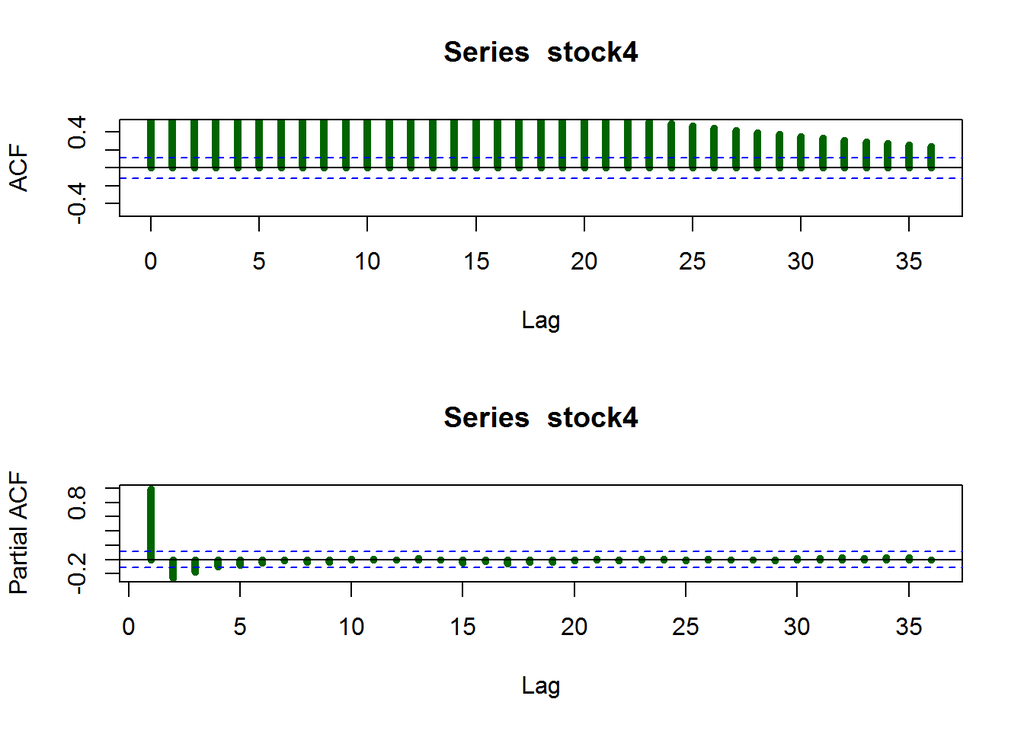

```r
par(mfrow = c(2, 1))
acf(stock4,
    lag.max = 36, # max lag for ACF
    ylim = c(-0.5, 0.5),   # limits for the y axis - we give c(min, max)
    lwd = 5,               # line width
    col = "dark green",
    na.action = na.pass)   # do not stop if there are missing values in the data
pacf(stock4,
     lag.max = 36,
     lwd = 5, col = "dark green",
     na.action = na.pass)
```

```r
par(mfrow = c(1, 1)) # we restore the original single panel
```

ACF and PACF suggest that maybe `ARIMA(1,1,1)` could be a sensible model for our fourth financial instrument stock4.

Lets apply first differencies

```r
stock4diff <- diff(stock4)
```

Lets plot first differencies for `stock4`

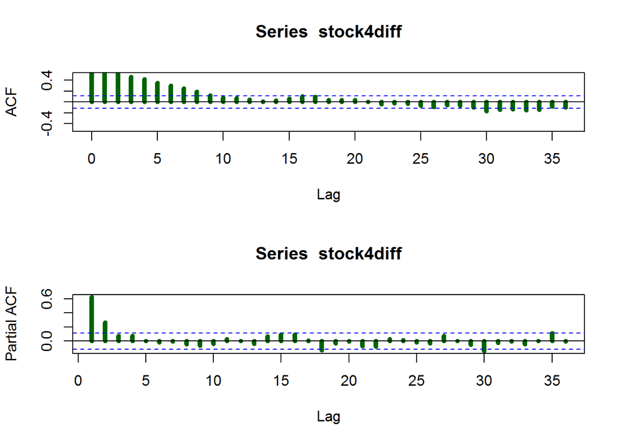

```r
par(mfrow = c(2, 1))
acf(stock4diff,
    lag.max = 36, # max lag for ACF
    ylim = c(-0.5, 0.5),   # limits for the y axis - we give c(min, max)
    lwd = 5,               # line width
    col = "dark green",
    na.action = na.pass)   # do not stop if there are missing values in the data
pacf(stock4diff,
     lag.max = 36,
     lwd = 5, col = "dark green",
     na.action = na.pass)
```

```r
par(mfrow = c(1, 1)) # we restore the original single panel
```

```r
stock4diff_diff <- diff(stock4diff)
```

Lets plot the data

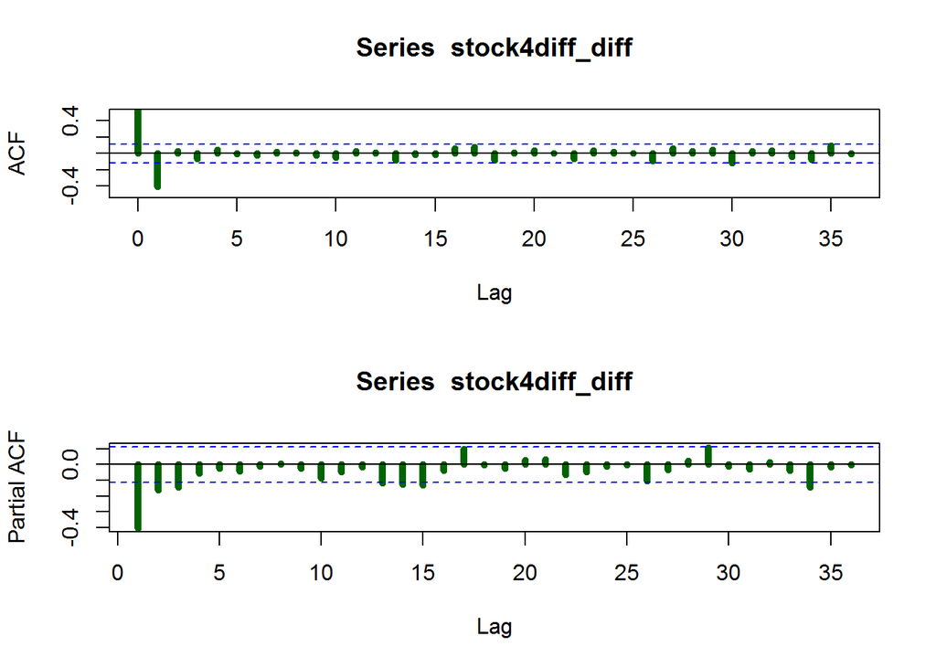

```r
par(mfrow = c(2, 1))
acf(stock4diff_diff,
    lag.max = 36, # max lag for ACF
    ylim = c(-0.5, 0.5),   # limits for the y axis - we give c(min, max)
    lwd = 5,               # line width
    col = "dark green",
    na.action = na.pass)   # do not stop if there are missing values in the data
pacf(stock4diff_diff,
     lag.max = 36,
     lwd = 5, col = "dark green",
     na.action = na.pass)
```

```r
par(mfrow = c(1, 1)) # we restore the original single panel
```

## 8.1.2 step 2 - model estimation

Lets build `ARIMA(1,1,1)`. We use `Arima()` function from the `forecast` package:

```r
arima111 <- Arima(stock4,  # variable
                  order = c(1, 1, 1)  # (p,d,q) parameters
                  )
```

By default the model on differenced data ($d = 1$) is estimated without a constant term. This means that first differences will fluctuate around 0.

The simple report doesn’t contain much content:

```r
arima111
```

```
## Series: stock4
## ARIMA(1,1,1)
##
## Coefficients:
##          ar1      ma1
##       0.8666  -0.4225
## s.e.  0.0396   0.0705
##
## sigma^2 estimated as 2.827:  log likelihood=-578.96
## AIC=1163.92   AICc=1164   BIC=1175.02
```

Lets use the `coeftest()` function from the `lmtest` package to test for significance of model parameters:

```r
coeftest(arima111)
```

```
##
## z test of coefficients:
##
##      Estimate Std. Error z value       Pr(>|z|)
## ar1  0.866586   0.039582 21.8936      < 2.2e-16 ***
## ma1 -0.422484   0.070477 -5.9946 0.000000002039 ***
## ---
## Signif. codes:  0 '***' 0.001 '**' 0.01 '*' 0.05 '.' 0.1 ' ' 1
```

Additional summary measures (eg. information criteria):

```r
summary(arima111)
```

```
## Series: stock4
## ARIMA(1,1,1)
##
## Coefficients:
##          ar1      ma1
##       0.8666  -0.4225
## s.e.  0.0396   0.0705
##
## sigma^2 estimated as 2.827:  log likelihood=-578.96
## AIC=1163.92   AICc=1164   BIC=1175.02
##
## Training set error measures:
##                       ME     RMSE      MAE         MPE      MAPE      MASE
## Training set -0.00958727 1.672957 1.330444 0.006538204 0.8528537 0.7611994
##                      ACF1
## Training set -0.009946999
```

Both parameters are significant.

However, using such syntax produces a model without a constant term. The constant is included by default when `d = 0`.

If we wanted to include a constant also when `d = 1`, we would use an additional argument `include.constant = T`:

```r
arima111_2 <- Arima(stock4,  # variable
                    order = c(1, 1, 1),  # (p,d,q) parameters
                    include.constant = TRUE)  # including a constant
```

A constant for a model with `d = 1` is reported as a drift parameter.

```r
coeftest(arima111_2)
```

```
##
## z test of coefficients:
##
##        Estimate Std. Error z value       Pr(>|z|)
## ar1    0.866372   0.039667 21.8410      < 2.2e-16 ***
## ma1   -0.422327   0.070528 -5.9881 0.000000002123 ***
## drift -0.043027   0.411341 -0.1046         0.9167
## ---
## Signif. codes:  0 '***' 0.001 '**' 0.01 '*' 0.05 '.' 0.1 ' ' 1
```

## 8.1.3 step 3 - model diagnostics

In the diagnostics step, we ask the fundamental question: are residuals of `arima111` model a realization of white noise process?

The `resid()` function applied to model results returns residuals

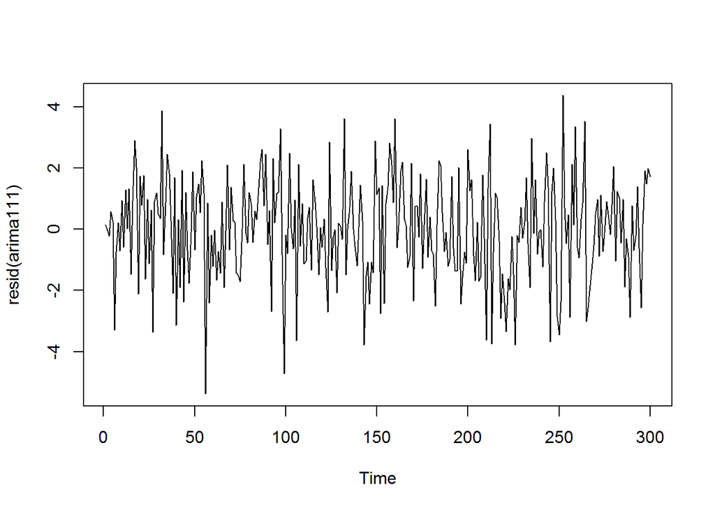

```r
plot(resid(arima111))
```

We can also use the `ggplot` approach to include date values on the horizontal axis:

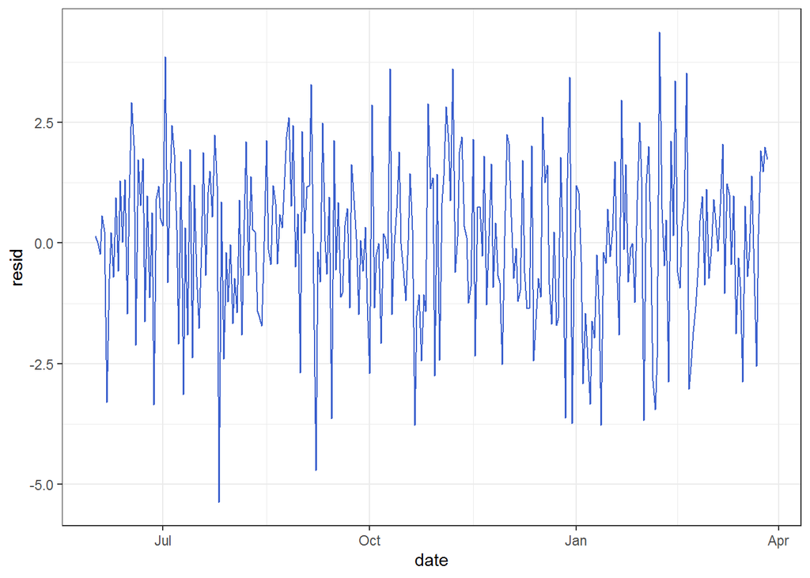

```r
tibble(
  date = index(stock4),
  resid = arima111 %>% resid() %>% as.numeric()
) %>%
  ggplot(aes(date, resid)) +
  geom_line(col = "royalblue3") +
  theme_bw()
```

Lets check the ACF and the PACF values:

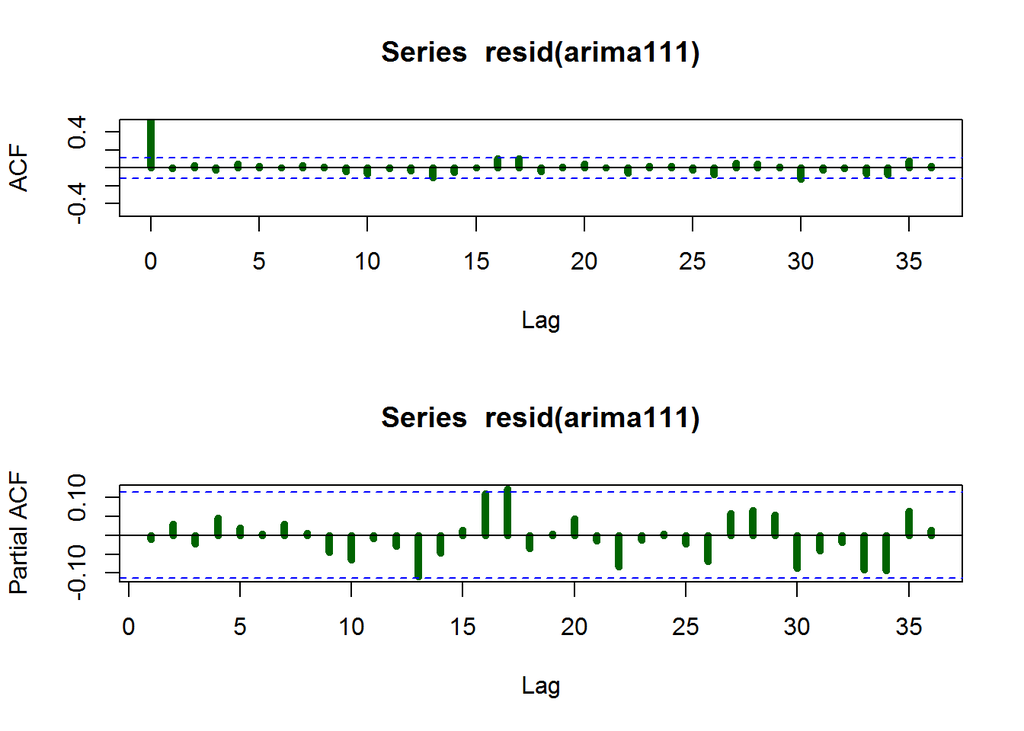

```r
par(mfrow = c(2, 1))
acf(resid(arima111),
    lag.max = 36,
    ylim = c(-0.5, 0.5),
    lwd = 5, col = "dark green",
    na.action = na.pass)
pacf(resid(arima111),
     lag.max = 36,
     lwd = 5, col = "dark green",
     na.action = na.pass)
```

```r
par(mfrow = c(1, 1))
```

Only lag 17 seem to be significant.

The Ljung-Box test (for a maximum of 10 lags):

```r
Box.test(resid(arima111), type = "Ljung-Box", lag = 10)
```

```
##
##  Box-Ljung test
##
## data:  resid(arima111)
## X-squared = 3.323, df = 10, p-value = 0.9728
```

At 5% we cannot reject the null about residuals being white noise, so ARIMA(1,1,1) is a correct fit.

## 8.1.4 Estimating parameters revisited

There is also a way to **automatically** find the most attractive model. We will use the `arima.best.AIC` and `arima.best.BIC` functions.

```r
arima.best.AIC <-
  auto.arima(stock4,
             d = 1,             # parameter d of ARIMA model
             max.p = 6,         # Maximum value of p
             max.q = 6,         # Maximum value of q
             max.order = 12,    # maximum p+q
             start.p = 1,       # Starting value of p in stepwise procedure
             start.q = 1,       # Starting value of q in stepwise procedure
             ic = "aic",        # Information criterion to be used in model selection.
             stepwise = FALSE,  # if FALSE considers all models
             allowdrift = TRUE, # include a constant
             trace = TRUE)      # show summary of all models considered
```

```
##
##  Fitting models using approximations to speed things up...
##
##  ARIMA(0,1,0)                    : 1332.908
##  ARIMA(0,1,0) with drift         : 1334.43
##  ARIMA(0,1,1)                    : 1249.605
##  ARIMA(0,1,1) with drift         : 1251.314
##  ARIMA(0,1,2)                    : 1207.736
##  ARIMA(0,1,2) with drift         : 1209.545
##  ARIMA(0,1,3)                    : 1196.682
##  ARIMA(0,1,3) with drift         : 1198.517
##  ARIMA(0,1,4)                    : 1185.007
##  ARIMA(0,1,4) with drift         : 1186.906
##  ARIMA(0,1,5)                    : 1179.772
##  ARIMA(0,1,5) with drift         : 1181.709
##  ARIMA(0,1,6)                    : 1178.276
##  ARIMA(0,1,6) with drift         : 1180.23
##  ARIMA(1,1,0)                    : 1185.489
##  ARIMA(1,1,0) with drift         : 1187.418
##  ARIMA(1,1,1)                    : 1162.621
##  ARIMA(1,1,1) with drift         : 1164.611
##  ARIMA(1,1,2)                    : 1164.373
##  ARIMA(1,1,2) with drift         : 1166.363
##  ARIMA(1,1,3)                    : 1166.357
##  ARIMA(1,1,3) with drift         : 1168.347
##  ARIMA(1,1,4)                    : 1166.947
##  ARIMA(1,1,4) with drift         : 1168.934
##  ARIMA(1,1,5)                    : 1168.738
##  ARIMA(1,1,5) with drift         : 1170.724
##  ARIMA(1,1,6)                    : 1170.143
##  ARIMA(1,1,6) with drift         : 1172.125
##  ARIMA(2,1,0)                    : 1165.944
##  ARIMA(2,1,0) with drift         : 1167.923
##  ARIMA(2,1,1)                    : 1165.36
##  ARIMA(2,1,1) with drift         : 1167.351
##  ARIMA(2,1,2)                    : 1167.067
##  ARIMA(2,1,2) with drift         : 1169.057
##  ARIMA(2,1,3)                    : 1169.028
##  ARIMA(2,1,3) with drift         : 1171.018
##  ARIMA(2,1,4)                    : 1166.837
```

[output cut: 53 more lines]

```
##  ARIMA(6,1,3)                    : 1172.638
##  ARIMA(6,1,3) with drift         : 1174.66
##  ARIMA(6,1,4)                    : 1168.356
##  ARIMA(6,1,4) with drift         : 1170.314
##  ARIMA(6,1,5)                    : Inf
##  ARIMA(6,1,5) with drift         : Inf
##  ARIMA(6,1,6)                    : Inf
##  ARIMA(6,1,6) with drift         : Inf
##
##  Now re-fitting the best model(s) without approximations...
##
##
##
##
##  Best model: ARIMA(1,1,1)
```

This function estimate models with all possible combinations of model orders. However, it does not remove intermediate lags.

The results might be surprising.

```r
coeftest(arima.best.AIC)
```

```
##
## z test of coefficients:
##
##      Estimate Std. Error z value       Pr(>|z|)
## ar1  0.866586   0.039582 21.8936      < 2.2e-16 ***
## ma1 -0.422484   0.070477 -5.9946 0.000000002039 ***
## ---
## Signif. codes:  0 '***' 0.001 '**' 0.01 '*' 0.05 '.' 0.1 ' ' 1
```

From our test results it seems that the best fit is ARIMA(1,1,1).

```r
AIC(arima.best.AIC, arima111_2)
```

```
##                df      AIC
## arima.best.AIC  3 1163.918
## arima111_2      4 1165.907
```

The AIC is lower than for the best manually selected model.

```r
BIC(arima.best.AIC, arima111_2)
```

```
##                df      BIC
## arima.best.AIC  3 1175.019
## arima111_2      4 1180.709
```

The BIC is lower than for the best manually selected model as well.

Let’s preform the Ljung-Box test:

```r
Box.test(resid(arima.best.AIC), type = "Ljung-Box", lag =  5)
```

```
##
##  Box-Ljung test
##
## data:  resid(arima.best.AIC)
## X-squared = 1.2479, df = 5, p-value = 0.9402
```

```r
Box.test(resid(arima.best.AIC), type = "Ljung-Box", lag = 10)
```

```
##
##  Box-Ljung test
##
## data:  resid(arima.best.AIC)
## X-squared = 3.323, df = 10, p-value = 0.9728
```

```r
Box.test(resid(arima.best.AIC), type = "Ljung-Box", lag = 15)
```

```
##
##  Box-Ljung test
##
## data:  resid(arima.best.AIC)
## X-squared = 8.142, df = 15, p-value = 0.918
```

```r
Box.test(resid(arima.best.AIC), type = "Ljung-Box", lag = 20)
```

```
##
##  Box-Ljung test
##
## data:  resid(arima.best.AIC)
## X-squared = 15.943, df = 20, p-value = 0.7201
```

```r
Box.test(resid(arima.best.AIC), type = "Ljung-Box", lag = 25)
```

```
##
##  Box-Ljung test
##
## data:  resid(arima.best.AIC)
## X-squared = 17.47, df = 25, p-value = 0.8641
```

Let’s see correlograms for the residuals:

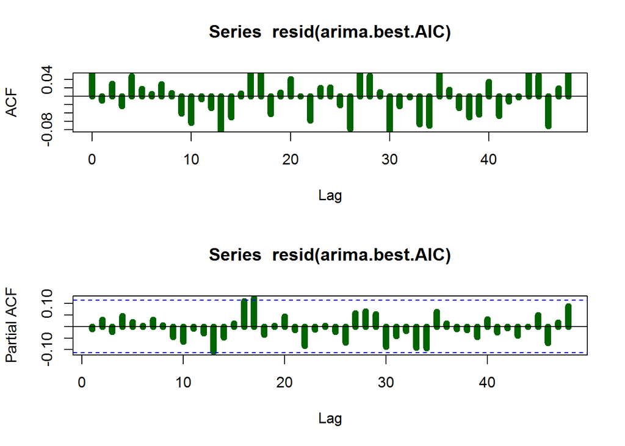

```r
par(mfrow = c(2, 1))
acf(resid(arima.best.AIC),
    lag.max = 48,
    lwd = 7,
    col = "dark green",
    na.action = na.pass,
    ylim = c(-0.08, 0.05))
pacf(resid(arima.best.AIC),
     lag.max = 48,
     lwd = 7,
     col = "dark green",
     na.action = na.pass)
```

```r
par(mfrow = c(1, 1))
```

We observe significant effects around 16th-17th lags.

Now let’s search for the best model in terms of BIC criterion:

```r
arima.best.BIC <-
  auto.arima(stock4,
             d = 1,             # parameter d of ARIMA model
             max.p = 6,         # Maximum value of p
             max.q = 6,         # Maximum value of q
             max.order = 12,    # maximum p+q
             start.p = 1,       # Starting value of p in stepwise procedure
             start.q = 1,       # Starting value of q in stepwise procedure
             ic = "bic",        # Information criterion to be used in model selection.
             stepwise = FALSE,  # if FALSE considers all models
             allowdrift = TRUE, # include a constant
             trace = TRUE)      # show summary of all models considered
```

```
##
##  Fitting models using approximations to speed things up...
##
##  ARIMA(0,1,0)                    : 1336.609
##  ARIMA(0,1,0) with drift         : 1341.831
##  ARIMA(0,1,1)                    : 1257.006
##  ARIMA(0,1,1) with drift         : 1262.416
##  ARIMA(0,1,2)                    : 1218.837
##  ARIMA(0,1,2) with drift         : 1224.347
##  ARIMA(0,1,3)                    : 1211.484
##  ARIMA(0,1,3) with drift         : 1217.019
##  ARIMA(0,1,4)                    : 1203.509
##  ARIMA(0,1,4) with drift         : 1209.109
##  ARIMA(0,1,5)                    : 1201.974
##  ARIMA(0,1,5) with drift         : 1207.612
##  ARIMA(0,1,6)                    : 1204.179
##  ARIMA(0,1,6) with drift         : 1209.833
##  ARIMA(1,1,0)                    : 1192.89
##  ARIMA(1,1,0) with drift         : 1198.519
##  ARIMA(1,1,1)                    : 1173.722
##  ARIMA(1,1,1) with drift         : 1179.413
##  ARIMA(1,1,2)                    : 1179.175
##  ARIMA(1,1,2) with drift         : 1184.865
##  ARIMA(1,1,3)                    : 1184.859
##  ARIMA(1,1,3) with drift         : 1190.549
##  ARIMA(1,1,4)                    : 1189.149
##  ARIMA(1,1,4) with drift         : 1194.837
##  ARIMA(1,1,5)                    : 1194.641
##  ARIMA(1,1,5) with drift         : 1200.327
##  ARIMA(1,1,6)                    : 1199.747
##  ARIMA(1,1,6) with drift         : 1205.429
##  ARIMA(2,1,0)                    : 1177.045
##  ARIMA(2,1,0) with drift         : 1182.725
##  ARIMA(2,1,1)                    : 1180.162
##  ARIMA(2,1,1) with drift         : 1185.853
##  ARIMA(2,1,2)                    : 1185.569
##  ARIMA(2,1,2) with drift         : 1191.259
##  ARIMA(2,1,3)                    : 1191.23
##  ARIMA(2,1,3) with drift         : 1196.922
##  ARIMA(2,1,4)                    : 1192.74
```

[output cut: 53 more lines]

```
##  ARIMA(6,1,3)                    : 1209.642
##  ARIMA(6,1,3) with drift         : 1215.365
##  ARIMA(6,1,4)                    : 1209.061
##  ARIMA(6,1,4) with drift         : 1214.719
##  ARIMA(6,1,5)                    : Inf
##  ARIMA(6,1,5) with drift         : Inf
##  ARIMA(6,1,6)                    : Inf
##  ARIMA(6,1,6) with drift         : Inf
##
##  Now re-fitting the best model(s) without approximations...
##
##
##
##
##  Best model: ARIMA(1,1,1)
```

Let’s see the model with lowest BIC value:

```r
coeftest(arima.best.BIC)
```

```
##
## z test of coefficients:
##
##      Estimate Std. Error z value       Pr(>|z|)
## ar1  0.866586   0.039582 21.8936      < 2.2e-16 ***
## ma1 -0.422484   0.070477 -5.9946 0.000000002039 ***
## ---
## Signif. codes:  0 '***' 0.001 '**' 0.01 '*' 0.05 '.' 0.1 ' ' 1
```

This is `ARIMA(1,1,1)` without constant.

Let’s compare it with `arima.best.AIC`, `arima111_2` models, in terms of BIC and AIC values:

```r
BIC(arima.best.BIC, arima.best.AIC, arima111_2)
```

```
##                df      BIC
## arima.best.BIC  3 1175.019
## arima.best.AIC  3 1175.019
## arima111_2      4 1180.709
```

```r
AIC(arima.best.BIC, arima.best.AIC, arima111_2)
```

```
##                df      AIC
## arima.best.BIC  3 1163.918
## arima.best.AIC  3 1163.918
## arima111_2      4 1165.907
```

It has indeed the lowest BIC value and AIC value.

Next we do the same procedure with our `stock10`.

```r
arima.best.AIC.Stock10 <-
  auto.arima(stock10,
             d = 1,             # parameter d of ARIMA model
             max.p = 6,         # Maximum value of p
             max.q = 6,         # Maximum value of q
             max.order = 12,    # maximum p+q
             start.p = 1,       # Starting value of p in stepwise procedure
             start.q = 1,       # Starting value of q in stepwise procedure
             ic = "aic",        # Information criterion to be used in model selection.
             stepwise = FALSE,  # if FALSE considers all models
             allowdrift = TRUE, # include a constant
             trace = TRUE)      # show summary of all models considered
```

```
##
##  Fitting models using approximations to speed things up...
##
##  ARIMA(0,1,0)                    : 1047.941
##  ARIMA(0,1,0) with drift         : 1049.457
##  ARIMA(0,1,1)                    : 959.4931
##  ARIMA(0,1,1) with drift         : 961.1954
##  ARIMA(0,1,2)                    : 920.9017
##  ARIMA(0,1,2) with drift         : 922.7139
##  ARIMA(0,1,3)                    : 908.9763
##  ARIMA(0,1,3) with drift         : 910.8108
##  ARIMA(0,1,4)                    : 895.7083
##  ARIMA(0,1,4) with drift         : 897.6126
##  ARIMA(0,1,5)                    : 891.2083
##  ARIMA(0,1,5) with drift         : 893.1474
##  ARIMA(0,1,6)                    : 889.5311
##  ARIMA(0,1,6) with drift         : 891.4882
##  ARIMA(1,1,0)                    : 894.1744
##  ARIMA(1,1,0) with drift         : 896.1057
##  ARIMA(1,1,1)                    : 872.7693
##  ARIMA(1,1,1) with drift         : 874.7603
##  ARIMA(1,1,2)                    : 874.7395
##  ARIMA(1,1,2) with drift         : 876.7301
##  ARIMA(1,1,3)                    : 876.6732
##  ARIMA(1,1,3) with drift         : 878.6634
##  ARIMA(1,1,4)                    : 877.1449
##  ARIMA(1,1,4) with drift         : 879.1324
##  ARIMA(1,1,5)                    : 879.0541
##  ARIMA(1,1,5) with drift         : 881.0407
##  ARIMA(1,1,6)                    : 880.2182
##  ARIMA(1,1,6) with drift         : 882.2006
##  ARIMA(2,1,0)                    : 877.5309
##  ARIMA(2,1,0) with drift         : 879.5079
##  ARIMA(2,1,1)                    : 875.7464
##  ARIMA(2,1,1) with drift         : 877.7374
##  ARIMA(2,1,2)                    : 877.5657
##  ARIMA(2,1,2) with drift         : 879.5542
##  ARIMA(2,1,3)                    : 879.5487
##  ARIMA(2,1,3) with drift         : 881.5372
##  ARIMA(2,1,4)                    : 877.1901
```

[output cut: 53 more lines]

```
##  ARIMA(6,1,3)                    : 885.5377
##  ARIMA(6,1,3) with drift         : 887.5366
##  ARIMA(6,1,4)                    : 878.2868
##  ARIMA(6,1,4) with drift         : 880.2327
##  ARIMA(6,1,5)                    : Inf
##  ARIMA(6,1,5) with drift         : Inf
##  ARIMA(6,1,6)                    : 881.7624
##  ARIMA(6,1,6) with drift         : 877.0157
##
##  Now re-fitting the best model(s) without approximations...
##
##
##
##
##  Best model: ARIMA(1,1,1)
```

Let’s see the results.

```r
coeftest(arima.best.AIC.Stock10)
```

```
##
## z test of coefficients:
##
##      Estimate Std. Error z value       Pr(>|z|)
## ar1  0.867506   0.039463 21.9826      < 2.2e-16 ***
## ma1 -0.416523   0.071233 -5.8473 0.000000004996 ***
## ---
## Signif. codes:  0 '***' 0.001 '**' 0.01 '*' 0.05 '.' 0.1 ' ' 1
```

Again from our test results it seems that the best fit is ARIMA(1,1,1).

Let’s also perform the Ljung-Box test:

```r
Box.test(resid(arima.best.AIC.Stock10), type = "Ljung-Box", lag =  5)
```

```
##
##  Box-Ljung test
##
## data:  resid(arima.best.AIC.Stock10)
## X-squared = 1.0951, df = 5, p-value = 0.9545
```

```r
Box.test(resid(arima.best.AIC.Stock10), type = "Ljung-Box", lag = 10)
```

```
##
##  Box-Ljung test
##
## data:  resid(arima.best.AIC.Stock10)
## X-squared = 3.215, df = 10, p-value = 0.9759
```

```r
Box.test(resid(arima.best.AIC.Stock10), type = "Ljung-Box", lag = 15)
```

```
##
##  Box-Ljung test
##
## data:  resid(arima.best.AIC.Stock10)
## X-squared = 9.4079, df = 15, p-value = 0.8552
```

```r
Box.test(resid(arima.best.AIC.Stock10), type = "Ljung-Box", lag = 20)
```

```
##
##  Box-Ljung test
##
## data:  resid(arima.best.AIC.Stock10)
## X-squared = 17.722, df = 20, p-value = 0.6057
```

```r
Box.test(resid(arima.best.AIC.Stock10), type = "Ljung-Box", lag = 25)
```

```
##
##  Box-Ljung test
##
## data:  resid(arima.best.AIC.Stock10)
## X-squared = 19.475, df = 25, p-value = 0.7738
```

Let’s see correlograms for the residuals:

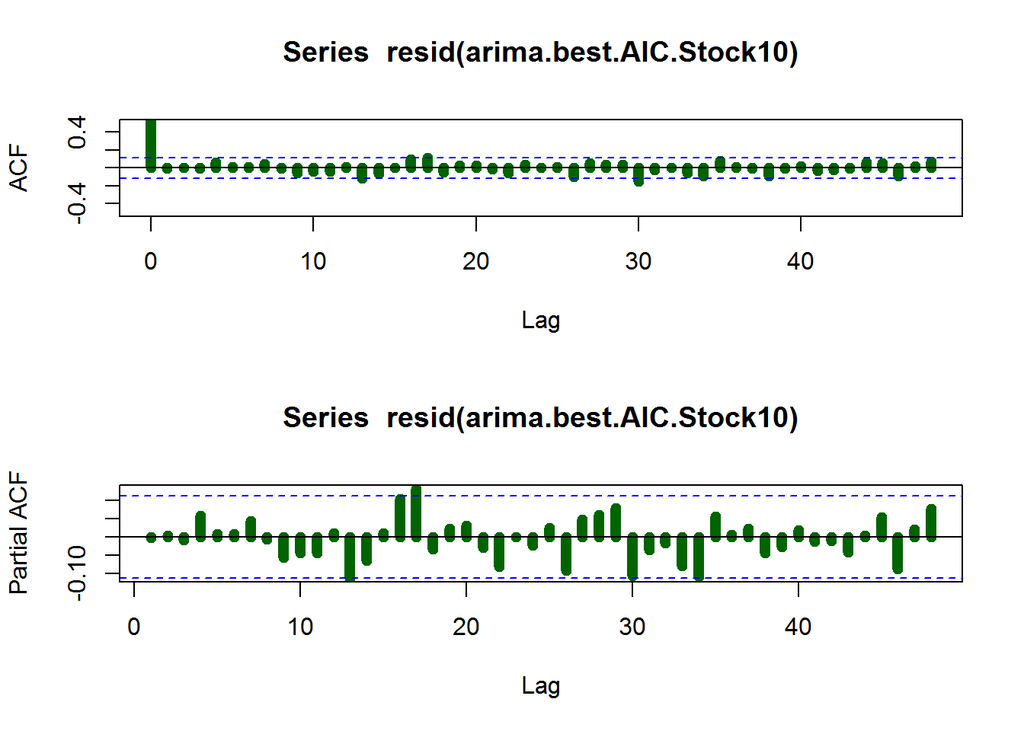

```r
par(mfrow = c(2, 1))
acf(resid(arima.best.AIC.Stock10),
    lag.max = 48,
    lwd = 7,
    col = "dark green",
    na.action = na.pass,
    ylim = c(-0.5, 0.5))
pacf(resid(arima.best.AIC.Stock10),
     lag.max = 48,
     lwd = 7,
     col = "dark green",
     na.action = na.pass)
```

```r
par(mfrow = c(1, 1))
```

Let’s now search for the best model in terms of BIC criterion again:

```r
arima.best.BIC.Stock10 <-
  auto.arima(stock10,
             d = 1,             # parameter d of ARIMA model
             max.p = 6,         # Maximum value of p
             max.q = 6,         # Maximum value of q
             max.order = 12,    # maximum p+q
             start.p = 1,       # Starting value of p in stepwise procedure
             start.q = 1,       # Starting value of q in stepwise procedure
             ic = "bic",        # Information criterion to be used in model selection.
             stepwise = FALSE,  # if FALSE considers all models
             allowdrift = TRUE, # include a constant
             trace = TRUE)      # show summary of all models considered
```

```
##
##  Fitting models using approximations to speed things up...
##
##  ARIMA(0,1,0)                    : 1051.641
##  ARIMA(0,1,0) with drift         : 1056.858
##  ARIMA(0,1,1)                    : 966.894
##  ARIMA(0,1,1) with drift         : 972.2967
##  ARIMA(0,1,2)                    : 932.003
##  ARIMA(0,1,2) with drift         : 937.5157
##  ARIMA(0,1,3)                    : 923.7781
##  ARIMA(0,1,3) with drift         : 929.3131
##  ARIMA(0,1,4)                    : 914.2105
##  ARIMA(0,1,4) with drift         : 919.8152
##  ARIMA(0,1,5)                    : 913.411
##  ARIMA(0,1,5) with drift         : 919.0505
##  ARIMA(0,1,6)                    : 915.4342
##  ARIMA(0,1,6) with drift         : 921.0918
##  ARIMA(1,1,0)                    : 901.5753
##  ARIMA(1,1,0) with drift         : 907.207
##  ARIMA(1,1,1)                    : 883.8706
##  ARIMA(1,1,1) with drift         : 889.5621
##  ARIMA(1,1,2)                    : 889.5412
##  ARIMA(1,1,2) with drift         : 895.2324
##  ARIMA(1,1,3)                    : 895.1754
##  ARIMA(1,1,3) with drift         : 900.8661
##  ARIMA(1,1,4)                    : 899.3475
##  ARIMA(1,1,4) with drift         : 905.0355
##  ARIMA(1,1,5)                    : 904.9572
##  ARIMA(1,1,5) with drift         : 910.6442
##  ARIMA(1,1,6)                    : 909.8217
##  ARIMA(1,1,6) with drift         : 915.5046
##  ARIMA(2,1,0)                    : 888.6322
##  ARIMA(2,1,0) with drift         : 894.3096
##  ARIMA(2,1,1)                    : 890.5482
##  ARIMA(2,1,1) with drift         : 896.2396
##  ARIMA(2,1,2)                    : 896.068
##  ARIMA(2,1,2) with drift         : 901.7569
##  ARIMA(2,1,3)                    : 901.7513
##  ARIMA(2,1,3) with drift         : 907.4403
##  ARIMA(2,1,4)                    : 903.0932
```

[output cut: 53 more lines]

```
##  ARIMA(6,1,3)                    : 922.5422
##  ARIMA(6,1,3) with drift         : 928.2415
##  ARIMA(6,1,4)                    : 918.9916
##  ARIMA(6,1,4) with drift         : 924.638
##  ARIMA(6,1,5)                    : Inf
##  ARIMA(6,1,5) with drift         : Inf
##  ARIMA(6,1,6)                    : 929.8682
##  ARIMA(6,1,6) with drift         : 928.8219
##
##  Now re-fitting the best model(s) without approximations...
##
##
##
##
##  Best model: ARIMA(1,1,1)
```

Again our automatic model selection indicate the ARIMA(1,1,1).

Lets now build our `ARIMA(1,1,1)` for Stock10, our tenth financial instrument.

```r
arima111 <- Arima(stock10,  # variable
                  order = c(1, 1, 1)  # (p,d,q) parameters
                  )
```

So our model of choice will be:

- `ARIMA(1,1,1)` - automated selection based on BIC
- `ARIMA(1,1,1)` - automated selection based on AIC

This model have: * lowest information criteria (AIC or BIC) * (almost) all parameters significant

## 8.2 Forecasting

Lets see few last observations of our data set

```r
tail(stock4, 10)
```

```
##                y4
## 2021-03-18 113.68
## 2021-03-19 112.32
## 2021-03-20 112.62
## 2021-03-21 111.67
## 2021-03-22 108.55
## 2021-03-23 107.11
## 2021-03-24 107.70
## 2021-03-25 108.88
## 2021-03-26 111.27
## 2021-03-27 114.23
```

We are going to produce forecasts for 10-periods ahead interval (since 2021-03-27). This will be our **out-of-sample** period.

Let’s make a prediction

```r
forecasts <- forecast(arima111_2, # model for prediction
                      h = 10) # how many periods outside the sample
```

Lets see the result

```r
forecasts
```

```
##     Point Forecast    Lo 80    Hi 80     Lo 95    Hi 95
## 301       116.0537 113.8953 118.2121 112.75271 119.3546
## 302       117.6279 113.8367 121.4191 111.82979 123.4260
## 303       118.9860 113.5131 124.4590 110.61589 127.3561
## 304       120.1569 112.9646 127.3492 109.15720 131.1566
## 305       121.1656 112.2375 130.0937 107.51119 134.8200
## 306       122.0337 111.3708 132.6966 105.72621 138.3412
## 307       122.7801 110.3964 135.1638 103.84080 141.7194
## 308       123.4210 109.3396 137.5024 101.88535 144.9566
## 309       123.9705 108.2210 139.7199  99.88379 148.0572
## 310       124.4408 107.0572 141.8244  97.85492 151.0267
```

```r
str(forecasts)
```

```
## List of 10
##  $ method   : chr "ARIMA(1,1,1) with drift"
##  $ model    :List of 19
##   ..$ coef     : Named num [1:3] 0.866 -0.422 -0.043
##   .. ..- attr(*, "names")= chr [1:3] "ar1" "ma1" "drift"
##   ..$ sigma2   : num 2.84
##   ..$ var.coef : num [1:3, 1:3] 0.001573 -0.001938 0.000535 -0.001938 0.004974 ...
##   .. ..- attr(*, "dimnames")=List of 2
##   .. .. ..$ : chr [1:3] "ar1" "ma1" "drift"
##   .. .. ..$ : chr [1:3] "ar1" "ma1" "drift"
##   ..$ mask     : logi [1:3] TRUE TRUE TRUE
##   ..$ loglik   : num -579
##   ..$ aic      : num 1166
##   ..$ arma     : int [1:7] 1 1 0 0 1 1 0
##   ..$ residuals: Time-Series [1:300] from 1 to 300: 0.1411 0.0395 -0.2122 0.5849 0.2537 ...
##   ..$ call     : language Arima(y = stock4, order = c(1, 1, 1), include.constant = TRUE, xreg = 1:300)
##   ..$ series   : chr "stock4"
##   ..$ code     : int 0
##   ..$ n.cond   : int 0
##   ..$ nobs     : int 299
##   ..$ model    :List of 10
##   .. ..$ phi  : num 0.866
##   .. ..$ theta: num -0.422
##   .. ..$ Delta: num 1
##   .. ..$ Z    : num [1:3] 1 0 1
##   .. ..$ a    : num [1:3] 3.003 -0.735 124.135
##   .. ..$ P    : num [1:3, 1:3] 0.00 0.00 1.19e-22 0.00 0.00 ...
##   .. ..$ T    : num [1:3, 1:3] 0.866 0 1 1 0 ...
##   .. ..$ V    : num [1:3, 1:3] 1 -0.422 0 -0.422 0.178 ...
##   .. ..$ h    : num 0
##   .. ..$ Pn   : num [1:3, 1:3] 1.00 -4.22e-01 -3.71e-23 -4.22e-01 1.78e-01 ...
##   ..$ aicc     : num 1166
##   ..$ bic      : num 1181
##   ..$ xreg     : int [1:300, 1] 1 2 3 4 5 6 7 8 9 10 ...
##   .. ..- attr(*, "dimnames")=List of 2
##   .. .. ..$ : NULL
##   .. .. ..$ : chr "drift"
##   ..$ x        : Time-Series [1:300] from 1 to 300: 141 141 141 141 142 ...
##   ..$ fitted   : Time-Series [1:300] from 1 to 300: 141 141 141 141 141 ...
##   ..- attr(*, "class")= chr [1:3] "forecast_ARIMA" "ARIMA" "Arima"
##  $ level    : num [1:2] 80 95
##  $ mean     : Time-Series [1:10] from 301 to 310: 116 118 119 120 121 ...
##  $ lower    : Time-Series [1:10, 1:2] from 301 to 310: 114 114 114 113 112 ...
##   ..- attr(*, "dimnames")=List of 2
##   .. ..$ : NULL
##   .. ..$ : chr [1:2] "80%" "95%"
##  $ upper    : Time-Series [1:10, 1:2] from 301 to 310: 118 121 124 127 130 ...
##   ..- attr(*, "dimnames")=List of 2
##   .. ..$ : NULL
##   .. ..$ : chr [1:2] "80%" "95%"
##  $ x        : Time-Series [1:300] from 1 to 300: 141 141 141 141 142 ...
##  $ series   : chr "stock4"
##  $ fitted   : Time-Series [1:300] from 1 to 300: 141 141 141 141 141 ...
##  $ residuals: Time-Series [1:300] from 1 to 300: 0.1411 0.0395 -0.2122 0.5849 0.2537 ...
##  - attr(*, "class")= chr "forecast"
```

The forecasts are indexed with an observation number, not a date!

To extract the point forecast (the first column) we need to reference to the `mean` object:

```r
forecasts$mean
```

```
## Time Series:
## Start = 301
## End = 310
## Frequency = 1
##  [1] 116.0537 117.6279 118.9860 120.1569 121.1656 122.0337 122.7801 123.4210
##  [9] 123.9705 124.4408
```

Lets check the class of this object

```r
class(forecasts$mean)
```

```
## [1] "ts"
```

It is a `ts` object, not `xts`!

Anyway, the `as.numeric()` function allows to convert it to a simple numeric vector

```r
as.numeric(forecasts$mean)
```

```
##  [1] 116.0537 117.6279 118.9860 120.1569 121.1656 122.0337 122.7801 123.4210
##  [9] 123.9705 124.4408
```

The 80% and 95% confidence intervals are located in the `lower` and `upper` objects:

```r
forecasts$lower
```

```
## Time Series:
## Start = 301
## End = 310
## Frequency = 1
##          80%       95%
## 301 113.8953 112.75271
## 302 113.8367 111.82979
## 303 113.5131 110.61589
## 304 112.9646 109.15720
## 305 112.2375 107.51119
## 306 111.3708 105.72621
## 307 110.3964 103.84080
## 308 109.3396 101.88535
## 309 108.2210  99.88379
## 310 107.0572  97.85492
```

```r
forecasts$upper
```

```
## Time Series:
## Start = 301
## End = 310
## Frequency = 1
##          80%      95%
## 301 118.2121 119.3546
## 302 121.4191 123.4260
## 303 124.4590 127.3561
## 304 127.3492 131.1566
## 305 130.0937 134.8200
## 306 132.6966 138.3412
## 307 135.1638 141.7194
## 308 137.5024 144.9566
## 309 139.7199 148.0572
## 310 141.8244 151.0267
```

We are interested only in the second column (95% confidence interval).

If we wanted to easily put together both real data and the forecast on the plot, we would have to convert both to `ts` or both to `xts` objects.

The `xts` objects are more convenient and modern.

We need a `data.frame` with data and index of dates to create an `xts` object:

```r
forecasts_data <- data.frame(f_mean  = as.numeric(forecasts$mean),
                             f_lower = as.numeric(forecasts$lower[, 2]),
                             f_upper = as.numeric(forecasts$upper[, 2]))
```

Let’s see its first six observations:

```r
head(forecasts_data)
```

```
##     f_mean  f_lower  f_upper
## 1 116.0537 112.7527 119.3546
## 2 117.6279 111.8298 123.4260
## 3 118.9860 110.6159 127.3561
## 4 120.1569 109.1572 131.1566
## 5 121.1656 107.5112 134.8200
## 6 122.0337 105.7262 138.3412
```

Let’s add forcasted dates to our forecasted dataset.

```r
rownames(forecasts_data) <- seq(as.Date('2021-03-28'),as.Date('2021-04-06'), by = 1)

forecasts_data <- xts(forecasts_data, order.by=as.Date(rownames(forecasts_data)))
```

We now merge our forcasted data and original dataset of `stock4` together.

```r
stock4$date <- seq(as.Date('2021-03-28'),as.Date('2021-04-06'), by = 1)

stock4fcst <- cbind(stock4[,"y4"], forecasts_data)
tail(stock4fcst, n = 10)
```

```
##            y4   f_mean   f_lower  f_upper
## 2021-03-28 NA 116.0537 112.75271 119.3546
## 2021-03-29 NA 117.6279 111.82979 123.4260
## 2021-03-30 NA 118.9860 110.61589 127.3561
## 2021-03-31 NA 120.1569 109.15720 131.1566
## 2021-04-01 NA 121.1656 107.51119 134.8200
## 2021-04-02 NA 122.0337 105.72621 138.3412
## 2021-04-03 NA 122.7801 103.84080 141.7194
## 2021-04-04 NA 123.4210 101.88535 144.9566
## 2021-04-05 NA 123.9705  99.88379 148.0572
## 2021-04-06 NA 124.4408  97.85492 151.0267
```

Lets finally plot the figure with the forecast and original series.

Original data

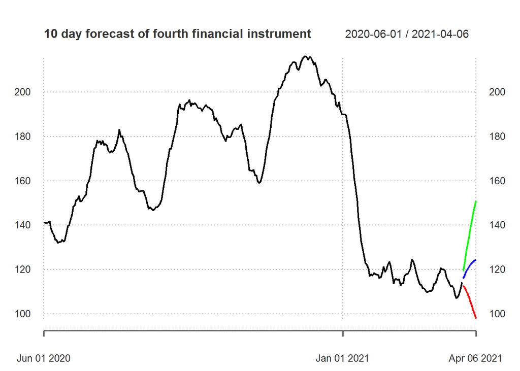

```r
plot(stock4fcst[, c("y4", "f_mean", "f_lower", "f_upper")],
     major.ticks = "years",
     grid.ticks.on = "years",
     grid.ticks.lty = 3,
     main = "10 day forecast of fourth financial instrument",
     col = c("black", "blue", "red", "green"))
```

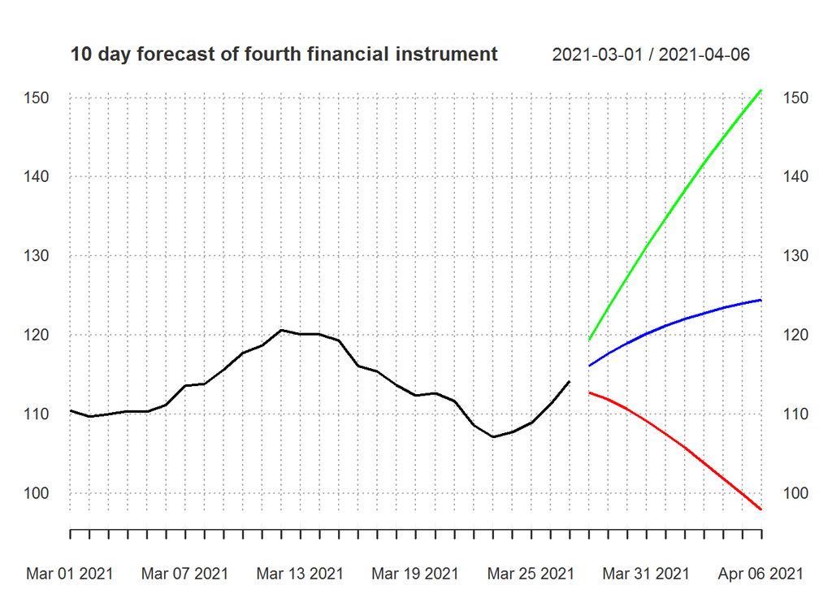

```r
plot(stock4fcst["2021-03/", # limit the rows
          c("y4", "f_mean", "f_lower", "f_upper")],
     major.ticks = "days",
     grid.ticks.on = "days",
     grid.ticks.lty = 3,
     main = "10 day forecast of fourth financial instrument",
     col = c("black", "blue", "red", "green"))
```

Now, we will assess forecast quality.

Real values - last 10 observations (*note we take 10 last observations from in-sample period*)

```r
stock4fcst$y4 <- c(stock4fcst$y4[291:300,])
stock4fcst1 <- tail(stock4fcst, 10)
stock4fcst1
```

```
##                y4   f_mean   f_lower  f_upper
## 2021-03-28 113.68 116.0537 112.75271 119.3546
## 2021-03-29 112.32 117.6279 111.82979 123.4260
## 2021-03-30 112.62 118.9860 110.61589 127.3561
## 2021-03-31 111.67 120.1569 109.15720 131.1566
## 2021-04-01 108.55 121.1656 107.51119 134.8200
## 2021-04-02 107.11 122.0337 105.72621 138.3412
## 2021-04-03 107.70 122.7801 103.84080 141.7194
## 2021-04-04 108.88 123.4210 101.88535 144.9566
## 2021-04-05 111.27 123.9705  99.88379 148.0572
## 2021-04-06 114.23 124.4408  97.85492 151.0267
```

Finally we can calculate popular measures of ex-post prediction errors

```r
stock4fcst1$mae   <-  abs(stock4fcst1$y4 - stock4fcst1$f_mean)
stock4fcst1$mse   <-  (stock4fcst1$y4 - stock4fcst1$f_mean) ^ 2
stock4fcst1$mape  <-  abs((stock4fcst1$y4 - stock4fcst1$f_mean)/stock4fcst1$y4)
stock4fcst1$amape <-  abs((stock4fcst1$y4 - stock4fcst1$f_mean)/(stock4fcst1$y4 + stock4fcst1$f_mean))
stock4fcst1
```

```
##                y4   f_mean   f_lower  f_upper       mae        mse       mape
## 2021-03-28 113.68 116.0537 112.75271 119.3546  2.373673   5.634325 0.02088031
## 2021-03-29 112.32 117.6279 111.82979 123.4260  5.307903  28.173831 0.04725697
## 2021-03-30 112.62 118.9860 110.61589 127.3561  6.366021  40.526224 0.05652656
## 2021-03-31 111.67 120.1569 109.15720 131.1566  8.486907  72.027588 0.07599988
## 2021-04-01 108.55 121.1656 107.51119 134.8200 12.615580 159.152850 0.11621907
## 2021-04-02 107.11 122.0337 105.72621 138.3412 14.923716 222.717290 0.13933074
## 2021-04-03 107.70 122.7801 103.84080 141.7194 15.080095 227.409255 0.14001945
## 2021-04-04 108.88 123.4210 101.88535 144.9566 14.540987 211.440295 0.13355058
## 2021-04-05 111.27 123.9705  99.88379 148.0572 12.700488 161.302393 0.11414117
## 2021-04-06 114.23 124.4408  97.85492 151.0267 10.210811 104.260653 0.08938817
##                 amape
## 2021-03-28 0.01033228
## 2021-03-29 0.02308307
## 2021-03-30 0.02748642
## 2021-03-31 0.03660881
## 2021-04-01 0.05491826
## 2021-04-02 0.06512819
## 2021-04-03 0.06542905
## 2021-04-04 0.06259546
## 2021-04-05 0.05398938
## 2021-04-06 0.04278198
```

Again let’s apply the same procedure to our `stock10`.

```r
tail(stock10, 10)
```

```
##               y10
## 2021-03-18 128.81
## 2021-03-19 128.23
## 2021-03-20 128.29
## 2021-03-21 127.47
## 2021-03-22 125.78
## 2021-03-23 124.80
## 2021-03-24 125.20
## 2021-03-25 125.76
## 2021-03-26 127.43
## 2021-03-27 129.26
```

Same procedure as before producing forecast for 10-periods ahead interval (since 2021-03-27). This will be our **out-of-sample** period.

Our prediction model:

```r
forecasts <- forecast(arima111, # model for prediction
                      h = 10) # how many periods outside the sample
```

Lets see the result

```r
forecasts
```

```
##     Point Forecast    Lo 80    Hi 80    Lo 95    Hi 95
## 301       130.4306 129.1056 131.7556 128.4042 132.4570
## 302       131.4461 129.1111 133.7810 127.8751 135.0170
## 303       132.3270 128.9491 135.7049 127.1610 137.4930
## 304       133.0912 128.6453 137.5371 126.2918 139.8906
## 305       133.7542 128.2289 139.2795 125.3039 142.2044
## 306       134.3293 127.7242 140.9344 124.2276 144.4309
## 307       134.8282 127.1512 142.5053 123.0872 146.5693
## 308       135.2610 126.5258 143.9963 121.9016 148.6205
## 309       135.6365 125.8609 145.4121 120.6860 150.5871
## 310       135.9622 125.1669 146.7576 119.4521 152.4723
```

```r
str(forecasts)
```

```
## List of 10
##  $ method   : chr "ARIMA(1,1,1)"
##  $ model    :List of 18
##   ..$ coef     : Named num [1:2] 0.868 -0.417
##   .. ..- attr(*, "names")= chr [1:2] "ar1" "ma1"
##   ..$ sigma2   : num 1.07
##   ..$ var.coef : num [1:2, 1:2] 0.00156 -0.00195 -0.00195 0.00507
##   .. ..- attr(*, "dimnames")=List of 2
##   .. .. ..$ : chr [1:2] "ar1" "ma1"
##   .. .. ..$ : chr [1:2] "ar1" "ma1"
##   ..$ mask     : logi [1:2] TRUE TRUE
##   ..$ loglik   : num -434
##   ..$ aic      : num 873
##   ..$ arma     : int [1:7] 1 1 0 0 1 1 0
##   ..$ residuals: Time-Series [1:300] from 1 to 300: 0.1459999 -0.0001259 -0.0000374 0.0794861 0.4030661 ...
##   ..$ call     : language Arima(y = stock10, order = c(1, 1, 1))
##   ..$ series   : chr "stock10"
##   ..$ code     : int 0
##   ..$ n.cond   : int 0
##   ..$ nobs     : int 299
##   ..$ model    :List of 10
##   .. ..$ phi  : num 0.868
##   .. ..$ theta: num -0.417
##   .. ..$ Delta: num 1
##   .. ..$ Z    : num [1:3] 1 0 1
##   .. ..$ a    : num [1:3] 1.83 -0.417 127.43
##   .. ..$ P    : num [1:3, 1:3] 0.00 0.00 1.38e-21 0.00 0.00 ...
##   .. ..$ T    : num [1:3, 1:3] 0.868 0 1 1 0 ...
##   .. ..$ V    : num [1:3, 1:3] 1 -0.417 0 -0.417 0.173 ...
##   .. ..$ h    : num 0
##   .. ..$ Pn   : num [1:3, 1:3] 1.00 -4.17e-01 -4.38e-22 -4.17e-01 1.73e-01 ...
##   ..$ aicc     : num 873
##   ..$ bic      : num 884
##   ..$ x        : Time-Series [1:300] from 1 to 300: 146 146 146 146 147 ...
##   ..$ fitted   : Time-Series [1:300] from 1 to 300: 146 146 146 146 146 ...
##   ..- attr(*, "class")= chr [1:3] "forecast_ARIMA" "ARIMA" "Arima"
##  $ level    : num [1:2] 80 95
##  $ mean     : Time-Series [1:10] from 301 to 310: 130 131 132 133 134 ...
##  $ lower    : Time-Series [1:10, 1:2] from 301 to 310: 129 129 129 129 128 ...
##   ..- attr(*, "dimnames")=List of 2
##   .. ..$ : NULL
##   .. ..$ : chr [1:2] "80%" "95%"
##  $ upper    : Time-Series [1:10, 1:2] from 301 to 310: 132 134 136 138 139 ...
##   ..- attr(*, "dimnames")=List of 2
##   .. ..$ : NULL
##   .. ..$ : chr [1:2] "80%" "95%"
##  $ x        : Time-Series [1:300] from 1 to 300: 146 146 146 146 147 ...
##  $ series   : chr "stock10"
##  $ fitted   : Time-Series [1:300] from 1 to 300: 146 146 146 146 146 ...
##  $ residuals: Time-Series [1:300] from 1 to 300: 0.1459999 -0.0001259 -0.0000374 0.0794861 0.4030661 ...
##  - attr(*, "class")= chr "forecast"
```

The forecasts are indexed with an observation number, not a date!

We extract the point forecast (the first column) by referencing the `mean` object:

```r
forecasts$mean
```

```
## Time Series:
## Start = 301
## End = 310
## Frequency = 1
##  [1] 130.4306 131.4461 132.3270 133.0912 133.7542 134.3293 134.8282 135.2610
##  [9] 135.6365 135.9622
```

Lets check the class of this object

```r
class(forecasts$mean)
```

```
## [1] "ts"
```

As before it is a `ts` object, not `xts`!

We use `as.numeric()` function to convert to a numeric vector

```r
as.numeric(forecasts$mean)
```

```
##  [1] 130.4306 131.4461 132.3270 133.0912 133.7542 134.3293 134.8282 135.2610
##  [9] 135.6365 135.9622
```

The 80% and 95% confidence intervals are located in the `lower` and `upper` objects:

```r
forecasts$lower
```

```
## Time Series:
## Start = 301
## End = 310
## Frequency = 1
##          80%      95%
## 301 129.1056 128.4042
## 302 129.1111 127.8751
## 303 128.9491 127.1610
## 304 128.6453 126.2918
## 305 128.2289 125.3039
## 306 127.7242 124.2276
## 307 127.1512 123.0872
## 308 126.5258 121.9016
## 309 125.8609 120.6860
## 310 125.1669 119.4521
```

```r
forecasts$upper
```

```
## Time Series:
## Start = 301
## End = 310
## Frequency = 1
##          80%      95%
## 301 131.7556 132.4570
## 302 133.7810 135.0170
## 303 135.7049 137.4930
## 304 137.5371 139.8906
## 305 139.2795 142.2044
## 306 140.9344 144.4309
## 307 142.5053 146.5693
## 308 143.9963 148.6205
## 309 145.4121 150.5871
## 310 146.7576 152.4723
```

Our point of interest is the second column (95% confidence interval).

Same procedure as before, we need a `data.frame` with data and index of dates to create an `xts` object:

```r
forecasts_data <- data.frame(f_mean  = as.numeric(forecasts$mean),
                             f_lower = as.numeric(forecasts$lower[, 2]),
                             f_upper = as.numeric(forecasts$upper[, 2]))
```

Let’s see its first six observations:

```r
head(forecasts_data)
```

```
##     f_mean  f_lower  f_upper
## 1 130.4306 128.4042 132.4570
## 2 131.4461 127.8751 135.0170
## 3 132.3270 127.1610 137.4930
## 4 133.0912 126.2918 139.8906
## 5 133.7542 125.3039 142.2044
## 6 134.3293 124.2276 144.4309
```

Let’s add forecasted dates to our forecasted dataset.

```r
rownames(forecasts_data) <- seq(as.Date('2021-03-28'),as.Date('2021-04-06'), by = 1)

forecasts_data <- xts(forecasts_data, order.by=as.Date(rownames(forecasts_data)))
```

We now merge our forecasted data and original dataset of `Stock10` together.

```r
stock10$date <- seq(as.Date('2021-03-28'),as.Date('2021-04-06'), by = 1)

stock10fcst <- cbind(stock10[,"y10"], forecasts_data)
tail(stock10fcst, n = 10)
```

```
##            y10   f_mean  f_lower  f_upper
## 2021-03-28  NA 130.4306 128.4042 132.4570
## 2021-03-29  NA 131.4461 127.8751 135.0170
## 2021-03-30  NA 132.3270 127.1610 137.4930
## 2021-03-31  NA 133.0912 126.2918 139.8906
## 2021-04-01  NA 133.7542 125.3039 142.2044
## 2021-04-02  NA 134.3293 124.2276 144.4309
## 2021-04-03  NA 134.8282 123.0872 146.5693
## 2021-04-04  NA 135.2610 121.9016 148.6205
## 2021-04-05  NA 135.6365 120.6860 150.5871
## 2021-04-06  NA 135.9622 119.4521 152.4723
```

Lets finally plot the figure with the forecast and original series.

Original data

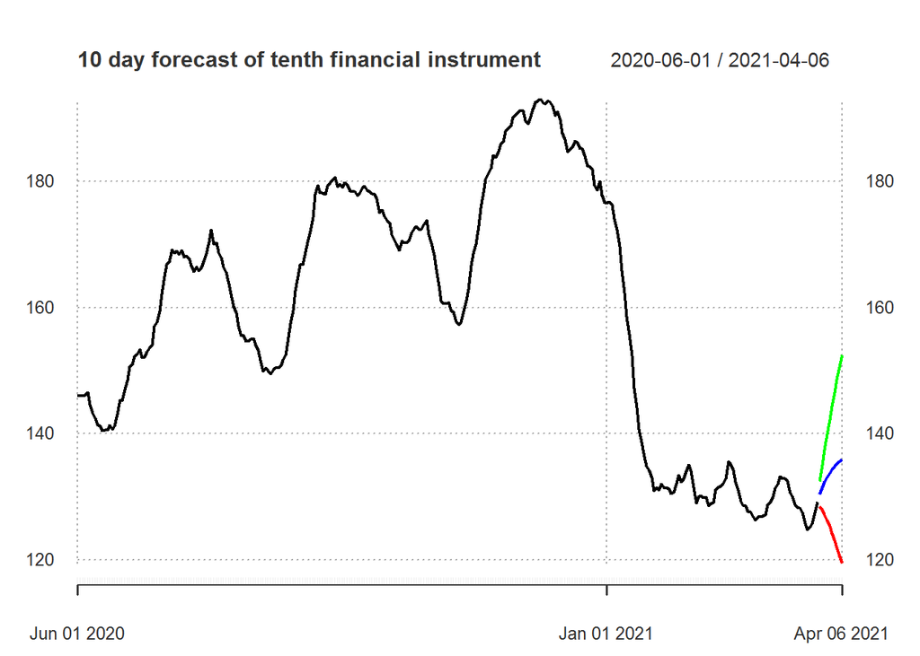

```r
plot(stock10fcst[, c("y10", "f_mean", "f_lower", "f_upper")],
     major.ticks = "years",
     grid.ticks.on = "years",
     grid.ticks.lty = 3,
     main = "10 day forecast of tenth financial instrument",
     col = c("black", "blue", "red", "green"))
```

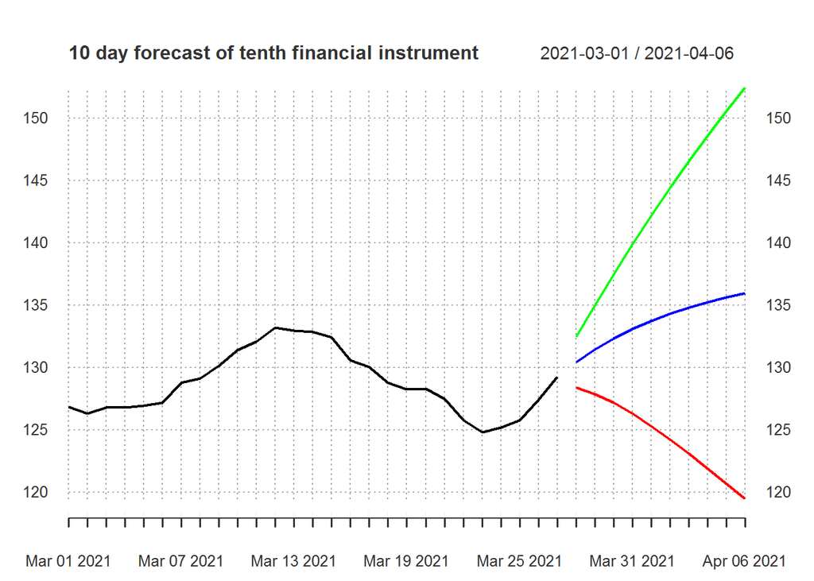

```r
plot(stock10fcst["2021-03/", # limit the rows
          c("y10", "f_mean", "f_lower", "f_upper")],
     major.ticks = "days",
     grid.ticks.on = "days",
     grid.ticks.lty = 3,
     main = "10 day forecast of tenth financial instrument",
     col = c("black", "blue", "red", "green"))
```

It looks okay.

Next we assess forecast quality for `stock10`.

Last 10 observations

```r
stock10fcst$y10 <- c(stock10fcst$y10[291:300,])
stock10fcst1 <- tail(stock10fcst, 10)
stock10fcst1
```

```
##               y10   f_mean  f_lower  f_upper
## 2021-03-28 128.81 130.4306 128.4042 132.4570
## 2021-03-29 128.23 131.4461 127.8751 135.0170
## 2021-03-30 128.29 132.3270 127.1610 137.4930
## 2021-03-31 127.47 133.0912 126.2918 139.8906
## 2021-04-01 125.78 133.7542 125.3039 142.2044
## 2021-04-02 124.80 134.3293 124.2276 144.4309
## 2021-04-03 125.20 134.8282 123.0872 146.5693
## 2021-04-04 125.76 135.2610 121.9016 148.6205
## 2021-04-05 127.43 135.6365 120.6860 150.5871
## 2021-04-06 129.26 135.9622 119.4521 152.4723
```

Finally we can calculate popular measures of ex-post prediction errors

```r
stock10fcst1$mae   <-  abs(stock10fcst1$y10 - stock10fcst1$f_mean)
stock10fcst1$mse   <-  (stock10fcst1$y10 - stock10fcst1$f_mean) ^ 2
stock10fcst1$mape  <-  abs((stock10fcst1$y10 - stock10fcst1$f_mean)/stock10fcst1$y10)
stock10fcst1$amape <-  abs((stock10fcst1$y10 - stock10fcst1$f_mean)/(stock10fcst1$y10 + stock10fcst1$f_mean))
stock10fcst1
```

```
##               y10   f_mean  f_lower  f_upper      mae      mse       mape
## 2021-03-28 128.81 130.4306 128.4042 132.4570 1.620574  2.62626 0.01258112
## 2021-03-29 128.23 131.4461 127.8751 135.0170 3.216054 10.34301 0.02508036
## 2021-03-30 128.29 132.3270 127.1610 137.4930 4.036989 16.29728 0.03146769
## 2021-03-31 127.47 133.0912 126.2918 139.8906 5.621206 31.59796 0.04409827
## 2021-04-01 125.78 133.7542 125.3039 142.2044 7.974169 63.58736 0.06339775
## 2021-04-02 124.80 134.3293 124.2276 144.4309 9.529293 90.80742 0.07635651
## 2021-04-03 125.20 134.8282 123.0872 146.5693 9.628216 92.70255 0.07690268
## 2021-04-04 125.76 135.2610 121.9016 148.6205 9.501035 90.26967 0.07554895
## 2021-04-05 127.43 135.6365 120.6860 150.5871 8.206509 67.34678 0.06440013
## 2021-04-06 129.26 135.9622 119.4521 152.4723 6.702234 44.91994 0.05185080
##                  amape
## 2021-03-28 0.006251236
## 2021-03-29 0.012384870
## 2021-03-30 0.015490124
## 2021-03-31 0.021573457
## 2021-04-01 0.030724928
## 2021-04-02 0.036774278
## 2021-04-03 0.037027582
## 2021-04-04 0.036399501
## 2021-04-05 0.031195566
## 2021-04-06 0.025270257
```

As a result we were able to produce 10-steps ahead forecast for both our under analysis financial instruments, respectively `stock4` and `stock10`.